# Analysis of Multi-view and Multi-modal Classification Approaches: Quantitative analysis

#### 3.2.2.6 Effect sizes discussion (Cliff’s Delta vs r Effect Size)

We calculated two different effect size measures for the same comparison, and they’ve given quite different results, for example for F-score we have:

- Cliff’s Delta = 0.1207 (negligible effect)
- r Effect Size = 0.7948017 (large effect)

This is a substantial discrepancy that requires explanation.

1. Why the Discrepancy Exists?

Because, these two effect size measures calculate fundamentally different things:

- Cliff’s Delta - Measures the degree of overlap between two distributions. Focuses on how often values from one group exceed values from another group. Ranges from -1 to 1, with 0 indicating complete overlap. Is less sensitive to outliers and extreme differences.
- r Effect Size (based on Z-statistic) - Measures the standardized strength of the relationship. Derived from the Z-statistic, which reflects the statistical significance. Ranges from 0 to 1, with higher values indicating stronger effects. Is more sensitive to the p-value of the test.

Technical Explanation:

- The r effect size we calculated depends heavily on the p-value of Wilcoxon test. When p-values are very small (as in our case), the Z-value becomes very large, which in turn inflates the r effect size. The calculation r = Z/sqrt(n) means that r is directly proportional to how statistically significant our result is.
- Cliff’s Delta, on the other hand, is calculated based on the actual data values and their relative positions, regardless of how statistically significant the difference is.
2. Which One Is More Accurate?

Neither is “wrong” - they just measure different aspects of our data:

- Cliff’s Delta is telling for us: “The distributions of scores for combinations and single views have substantial overlap, with combinations only slightly outperforming single views in terms of raw score comparisons.”
- r Effect Size is telling for us: “The difference between combinations and single views is highly statistically significant and unlikely to be due to chance.”
3. What’s Going On in our Specific Data

Based on these results, our data likely has these characteristics:

- The differences between combinations and single views are consistently in one direction (probably combinations > single in most pairs) - There are enough pairs in our sample to make even these small differences statistically significant (hence the large r effect size)
- The magnitude of these differences is relatively small (hence the small Cliff’s Delta) - The data might have some tied ranks or near-ties, which affects Cliff’s Delta calculation

#### 3.2.2.7 Simple statistics of pairs comparision

Calculate the percentage of pairs where combinations of views outperform single views. Calculate the median difference to understand the typical magnitude. Create a histogram of the differences

```
##
## acc- 82.17822% of pairs show combination view > single view
## acc- Median difference:2
```

```
##
## prec- 81.81818% of pairs show combination view > single view
## prec- Median difference:1.52
```

```
##
## rec- 100% of pairs show combination view > single view
## rec- Median difference:5.93
```

```
##
## f1score- 93% of pairs show combination view > single view
## f1score- Median difference:2.525
```

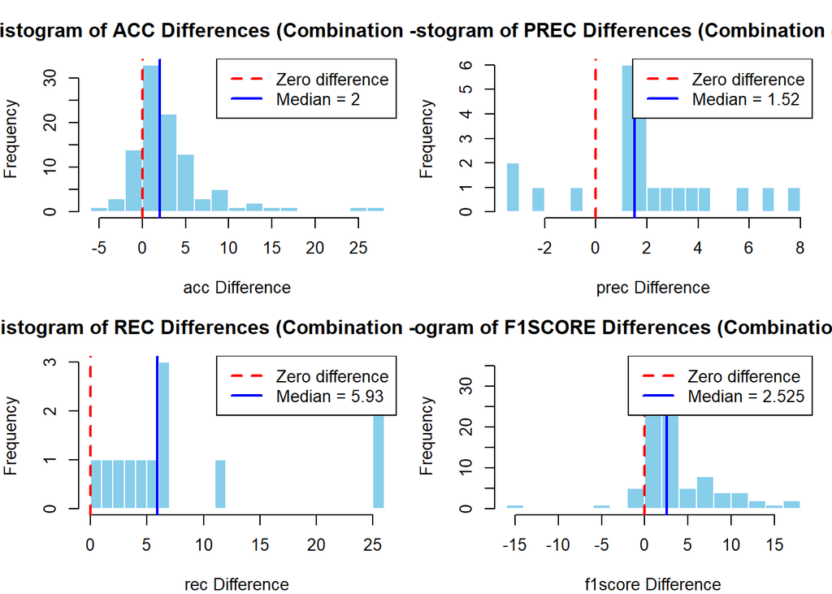

```r
# Define the metrics to analyse
metrics <- c("acc", "prec", "rec", "f1score")

# Set up a 2x2 plotting layout
par(mfrow = c(2, 2), mar = c(4, 4, 3, 1))

# Analyse each metric and store the differences
diff_list <- list()
for (metric in metrics) {
  diff_list[[metric]] <- analyze_differences(metric, data_clean)
}
```

```r
# Reset the plotting layout
par(mfrow = c(1, 1))
```

```r
# Create a summary table of all metrics
summary_table <- data.frame(
  Metric = metrics,
  Percent_Positive = sapply(diff_list, function(d)
    mean(d > 0, na.rm = TRUE) * 100),
  Median_Diff = sapply(diff_list, function(d)
    median(d, na.rm = TRUE)),
  Mean_Diff = sapply(diff_list, function(d)
    mean(d, na.rm = TRUE)),
  Min_Diff = sapply(diff_list, function(d)
    min(d, na.rm = TRUE)),
  Max_Diff = sapply(diff_list, function(d)
    max(d, na.rm = TRUE)),
  StdDev = sapply(diff_list, function(d)
    sd(d, na.rm = TRUE)),
  N_Pairs = sapply(diff_list, function(d)
    sum(!is.na(d)))
)
```

```r
knitr::kable(summary_table, caption = "Summary of Differences (Combination - Single)") %>% kableExtra::kable_styling()
```

Table 3.23: Table 3.24: Summary of Differences (Combination - Single)

|  | Metric | Percent_Positive | Median_Diff | Mean_Diff | Min_Diff | Max_Diff | StdDev | N_Pairs |
| --- | --- | --- | --- | --- | --- | --- | --- | --- |
| acc | acc | 82.17822 | 2.000 | 3.267822 | -5.11 | 27.98 | 5.061075 | 101 |
| prec | prec | 81.81818 | 1.520 | 1.865455 | -3.30 | 7.80 | 2.828556 | 22 |
| rec | rec | 100.00000 | 5.930 | 8.277500 | 0.40 | 25.50 | 8.483150 | 12 |
| f1score | f1score | 93.00000 | 2.525 | 3.503300 | -15.03 | 16.10 | 4.228347 | 100 |

## 3.3 Average-then-Test: Overcoming the shortcoming of pseudoreplication

Now, our quantitative analysis was conducted using a two-stage meta-analytic approach to ensure each study contributed a single, stable data point to the final analysis, thereby preventing pseudoreplication.

Stage 1: Data Preparation and Within-Study Aggregation

For each paper in our literature review, we extracted the reported performance scores for both the multi-view and single-view approaches. Paired differences were calculated for each available result within a single study. To create a single, representative performance metric for each study, we then calculated the mean of these paired differences. This procedure resulted in a final dataset where each study is represented by a single mean difference value for each relevant metric (Accuracy, F1-Score, etc.). This set of study-level mean differences forms the basis for our inferential testing.

Stage 2: Inferential Testing Across Studies

Research Question 1: Is there a significant difference in the mean reported outcomes across studies? To address this question, we employed a permutation test on the set of calculated study-level mean differences. This test directly evaluates whether the grand mean of these study-level outcomes is significantly different from zero, providing the primary answer to whether, on average, a multi-view approach yields a different result.

Research Question 2: Is this finding robust to the influence of outlier studies?

To complement the permutation test and assess the robustness of our findings, we applied a Wilcoxon signed-rank test to the exact same set of study-level mean differences. The purpose of this second test is to evaluate the central tendency (median) of the study-level outcomes. A significant result here would indicate that the effect is not merely driven by a few studies with extremely large means, but rather that a typical study in the literature also demonstrates an effect. This serves as a critical robustness check for the conclusion drawn from the permutation test.

Research Question 3: If we pick a random value from group singleview and a random value from group mutliview, what is the probability that the value from mutliview is larger, minus the probability that the value from singleview is larger?

To complement the Cliff’s Delta has been performed.

### 3.3.1 Data Preparation and Within-Study Aggregation: Statistical tests of the difference in the distributions of metrics values

Preparing data frame with outcomes (data points for each metric).

```r
view_diffs_per_article <- data.frame(
  bibtex = data_clean$bibtex,
  acc_view_text_diff = data_clean$`acc.view.combinations.text` - data_clean$`acc.view.single.text`,
  prec_view_text_diff = data_clean$`prec.view.combinations.text` - data_clean$`prec.view.single.text`,
  rec_view_text_diff = data_clean$`rec.view.combinations.text` - data_clean$`rec.view.single.text`,
  f1score_view_text_diff = data_clean$`f1score.view.combinations.text` - data_clean$`f1score.view.single.text`
)   %>%
  fill(bibtex, .direction = "down") %>%
  filter(!(is.na(acc_view_text_diff) &
           is.na(prec_view_text_diff) &
           is.na(rec_view_text_diff) &
           is.na(f1score_view_text_diff)))  %>%
group_by(bibtex)
```

#### 3.3.1.1 Differences in indicators values

Aggregate metrics’ values per work (research paper).

```r
metrics_columns <- c("acc_view_text_diff", "prec_view_text_diff",
                     "rec_view_text_diff", "f1score_view_text_diff")

# Create summary for each bibtex and each metric
bibtex_summary <- view_diffs_per_article %>%
  group_by(.data[['bibtex']]) %>%
  summarise(
    across(all_of(metrics_columns), summary_stats_grouped, .names = "{.col}"),
    .groups = "drop"
  )

# Reshape the data to have metrics as rows for better readability
bibtex_summary_long <- bibtex_summary %>%
  pivot_longer(
    cols = -.data[['bibtex']],
    names_to = c("metric", "stat"),
    names_pattern = "(.+)\\.(.+)",
    values_to = "value"
  ) %>%
  pivot_wider(
    names_from = stat,
    values_from = value
  )

bibtex_summary_tables <- view_diffs_per_article %>%
  group_by(.data[['bibtex']]) %>%
  group_map(~ {
    paper_data <- .x[metrics_columns]
    stats_list <- lapply(paper_data, summary_stats_grouped)
    summary_df <- do.call(rbind, stats_list)
    summary_df$Metric <- rownames(summary_df)
    rownames(summary_df) <- NULL
    summary_df$bibtex <- .y$bibtex
    return(summary_df[, c("bibtex", "Metric", "Count", "Median", "Min", "Max", "Mean", "SD")])
  })

# Combine all tables
final_summary <- do.call(rbind, bibtex_summary_tables)
```

```r
knitr::kable(final_summary,
             caption = "Distribution of metrics per paper (bibtex)",
             digits = 3) %>%
  kableExtra::kable_styling() %>%
  kableExtra::collapse_rows(columns = 1, valign = "top")
```

Table 3.25: Table 3.26: Distribution of metrics per paper (bibtex)

| bibtex | Metric | Count | Median | Min | Max | Mean | SD |
| --- | --- | --- | --- | --- | --- | --- | --- |
| akhtiamov2019 | acc_view_text_diff | 0 | NA | NA | NA | NA | NA |
|  | prec_view_text_diff | 0 | NA | NA | NA | NA | NA |
|  | rec_view_text_diff | 1 | 0.400 | 0.400 | 0.400 | 0.400 | NA |
|  | f1score_view_text_diff | 0 | NA | NA | NA | NA | NA |
| aminim2009 | acc_view_text_diff | 6 | 10.250 | 5.700 | 16.900 | 10.800 | 5.164 |
|  | prec_view_text_diff | 0 | NA | NA | NA | NA | NA |
|  | rec_view_text_diff | 0 | NA | NA | NA | NA | NA |
|  | f1score_view_text_diff | 6 | 12.200 | 6.700 | 16.100 | 11.467 | 3.751 |
| aminim2010 | acc_view_text_diff | 0 | NA | NA | NA | NA | NA |
|  | prec_view_text_diff | 0 | NA | NA | NA | NA | NA |
|  | rec_view_text_diff | 0 | NA | NA | NA | NA | NA |
|  | f1score_view_text_diff | 48 | 2.000 | -0.700 | 13.600 | 2.244 | 2.132 |
| aminim2010b | acc_view_text_diff | 6 | 6.900 | 3.700 | 11.400 | 7.150 | 2.964 |
|  | prec_view_text_diff | 0 | NA | NA | NA | NA | NA |
|  | rec_view_text_diff | 0 | NA | NA | NA | NA | NA |
|  | f1score_view_text_diff | 6 | 8.000 | 5.100 | 10.700 | 7.983 | 2.233 |
| bhatt2019 | acc_view_text_diff | 2 | 26.990 | 26.000 | 27.980 | 26.990 | 1.400 |
|  | prec_view_text_diff | 0 | NA | NA | NA | NA | NA |
|  | rec_view_text_diff | 0 | NA | NA | NA | NA | NA |
|  | f1score_view_text_diff | 0 | NA | NA | NA | NA | NA |
| carmona2020 | acc_view_text_diff | 2 | 1.500 | 1.000 | 2.000 | 1.500 | 0.707 |
|  | prec_view_text_diff | 0 | NA | NA | NA | NA | NA |
|  | rec_view_text_diff | 0 | NA | NA | NA | NA | NA |
|  | f1score_view_text_diff | 2 | 1.500 | 1.000 | 2.000 | 1.500 | 0.707 |
| chens2019 | acc_view_text_diff | 0 | NA | NA | NA | NA | NA |
|  | prec_view_text_diff | 12 | 1.520 | 1.200 | 3.010 | 1.721 | 0.570 |
|  | rec_view_text_diff | 0 | NA | NA | NA | NA | NA |
|  | f1score_view_text_diff | 0 | NA | NA | NA | NA | NA |
| dasigiv2001 | acc_view_text_diff | 0 | NA | NA | NA | NA | NA |
|  | prec_view_text_diff | 4 | -1.590 | -3.250 | 4.160 | -0.568 | 3.288 |

[output cut: 98 more lines]

Verification of data points count

```r
combined_summary <- do.call(rbind, bibtex_summary_tables)

simple_metric_summary <- combined_summary %>%
  group_by(.data[['Metric']]) %>%
  summarise(
    Total_Papers = n(),
    Papers_with_Data = sum(Count > 0),
    Total_Observations = sum(Count),
    .groups = "drop"
  )
```

```r
knitr::kable(simple_metric_summary,
             caption = "Simple Metric Summary") %>%
  kableExtra::kable_styling()
```

Table 3.27: Table 3.28: Simple Metric Summary

| Metric | Total_Papers | Papers_with_Data | Total_Observations |
| --- | --- | --- | --- |
| acc_view_text_diff | 32 | 20 | 101 |
| f1score_view_text_diff | 32 | 17 | 100 |
| prec_view_text_diff | 32 | 5 | 22 |
| rec_view_text_diff | 32 | 6 | 12 |

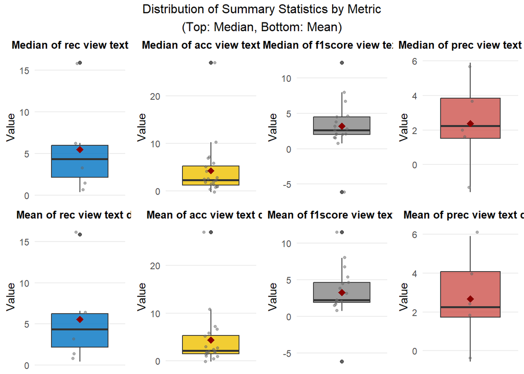

```r
# Prepare data for histograms - combine mean and median values
histogram_data <- final_summary %>%
  dplyr::select('bibtex', 'Metric', 'Mean', 'Median') %>%
  filter(!is.na(Mean) | !is.na(Median)) %>%
  pivot_longer(cols = c(.data[['Mean']], .data[['Median']]),
               names_to = "statistic",
               values_to = "value") %>%
  filter(!is.na(value))

# Create global palette for metrics
metrics_list <- unique(histogram_data$Metric)
global_palette <- stats::setNames(
  grDevices::colorRampPalette(ggsci::pal_jco("default")(4))(length(metrics_list)),
  metrics_list
)

# Create plots for median (top row)
median_plots <- lapply(metrics_list, function(metric) {
  create_summary_boxplot(histogram_data, metric, "Median", global_palette)
})

# Create plots for mean (bottom row)
mean_plots <- lapply(metrics_list, function(metric) {
  create_summary_boxplot(histogram_data, metric, "Mean", global_palette)
})

# Combine all plots in a 2x4 grid (median on top, mean on bottom)
all_plots <- c(median_plots, mean_plots)

# Arrange as 2 rows × 4 columns
grid.arrange(grobs = all_plots, ncol = 4, nrow = 2,
             top = "Distribution of Summary Statistics by Metric\n(Top: Median, Bottom: Mean)")
```

Better visualization i.e. enhanced version with consistent y-axis scales.

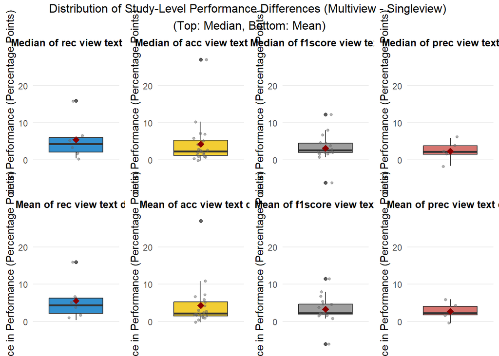

```r
# Calculate y-axis limits for each statistic
median_range <- histogram_data %>%
  filter(statistic == "Median") %>%
  pull(value) %>%
  range(na.rm = TRUE)

mean_range <- histogram_data %>%
  filter(statistic == "Mean") %>%
  pull(value) %>%
  range(na.rm = TRUE)

# Create scaled plots
median_plots_scaled <- lapply(metrics_list, function(metric) {
  create_summary_boxplot_scaled(histogram_data, metric, "Median", median_range, global_palette)
})

mean_plots_scaled <- lapply(metrics_list, function(metric) {
  create_summary_boxplot_scaled(histogram_data, metric, "Mean", mean_range, global_palette)
})

# Arrange scaled version
grid.arrange(grobs = c(median_plots_scaled, mean_plots_scaled),
             ncol = 4, nrow = 2,
             top = "Distribution of Study-Level Performance Differences (Multiview − Singleview) \n(Top: Median, Bottom: Mean)")
```

Visualization to article

```r
clean_data <- preprocess_for_plotting(histogram_data)

table(clean_data$Metric)
```

```
##
##  Accuracy  F1 Score Precision    Recall
##        40        34        10        12
```

```r
table(histogram_data$Metric)
```

```
##
##     acc_view_text_diff f1score_view_text_diff    prec_view_text_diff
##                     40                     34                     10
##     rec_view_text_diff
##                     12
```

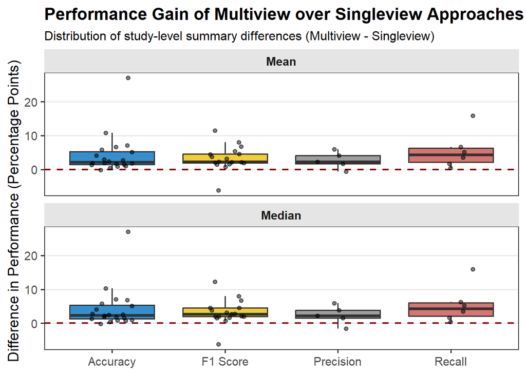

```r
metric_names <- c("Accuracy", "F1 Score", "Precision", "Recall")
palette_colors <- pal_jco("default")(length(metric_names))
my_palette <- setNames(palette_colors, metric_names)

final_faceted_plot <- create_faceted_plot(clean_data, palette = my_palette)

final_faceted_plot
```

```r
ggplot2::ggsave("fig-mv-difference.pdf", final_faceted_plot, width = 7.42, height = 8.46, units="in")
```

#### 3.3.1.2 Performs the Shapiro-Wilk test of normality of difference metrics’ values

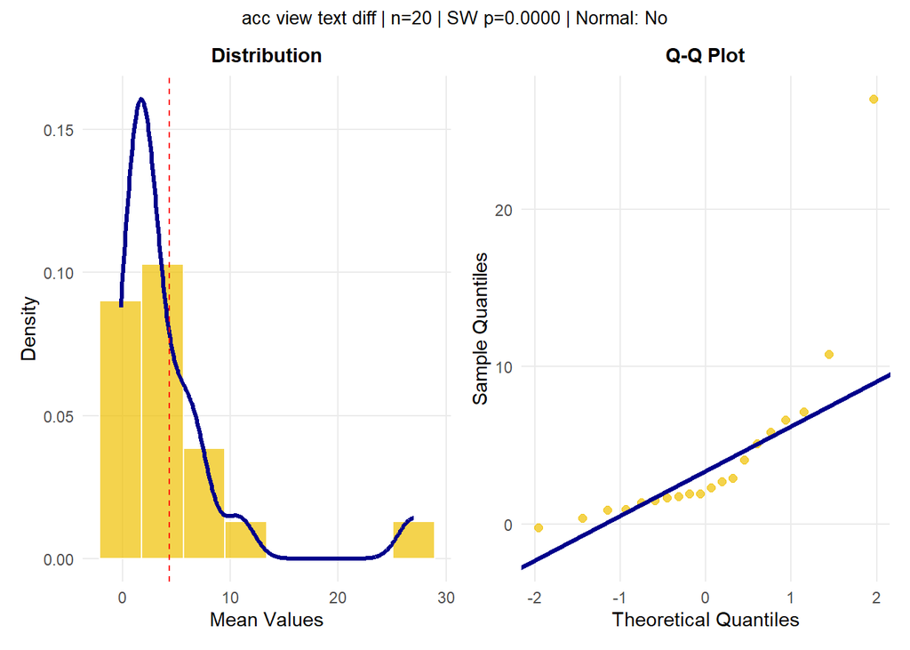

```r
global_palette <- stats::setNames(
  grDevices::colorRampPalette(ggsci::pal_jco("default")(4))(4),
  unique(histogram_data$Metric)
)

create_normality_plots(histogram_data, 'acc_view_text_diff', global_palette)
```

Remove outlier i.e. data points from two works about multilingual document classification.

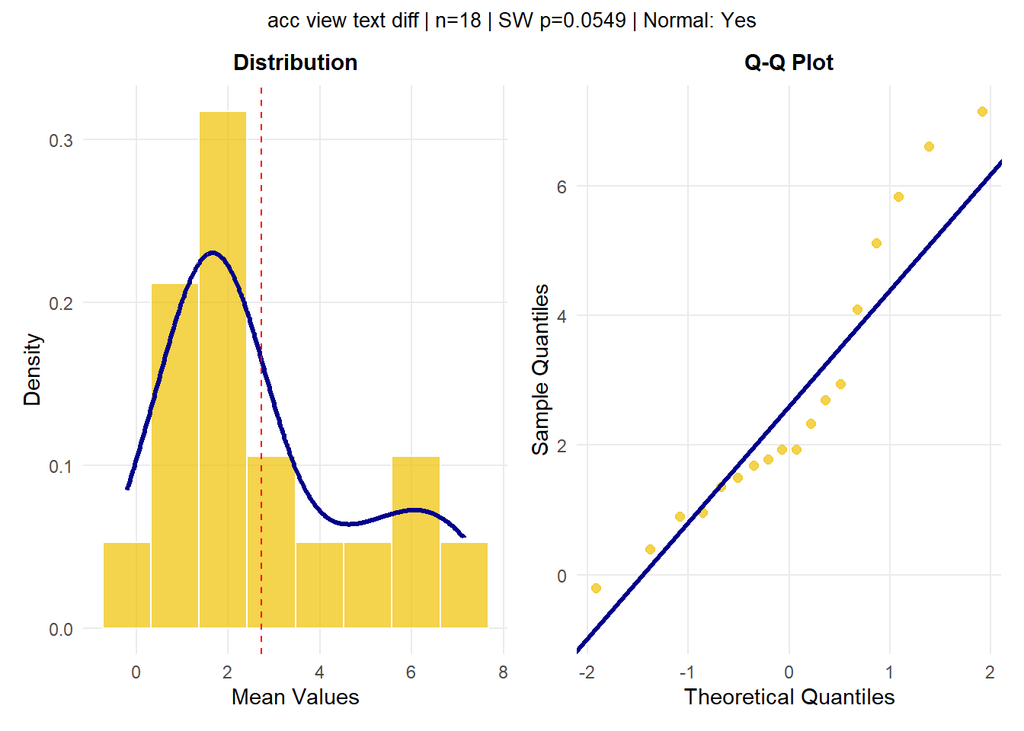

```r
global_palette <- stats::setNames(
  grDevices::colorRampPalette(ggsci::pal_jco("default")(4))(4),
  unique(histogram_data$Metric)
)

create_normality_plots(histogram_data %>% filter(!(bibtex %in% c('bhatt2019', 'aminim2009'))), 'acc_view_text_diff', global_palette)
```

```r
knitr::kable(histogram_data %>% filter(statistic  == 'Mean') %>% group_by(.data[['Metric']])  %>%  filter(Metric == 'acc_view_text_diff'), caption = "Distribution of extracted indicators values per papers") %>% kableExtra::kable_styling()
```

Table 3.29: Table 3.30: Distribution of extracted indicators values per papers

| bibtex | Metric | statistic | value |
| --- | --- | --- | --- |
| aminim2009 | acc_view_text_diff | Mean | 10.8000000 |
| aminim2010b | acc_view_text_diff | Mean | 7.1500000 |
| bhatt2019 | acc_view_text_diff | Mean | 26.9900000 |
| carmona2020 | acc_view_text_diff | Mean | 1.5000000 |
| fakri2015 | acc_view_text_diff | Mean | 1.7750000 |
| ferreira2018 | acc_view_text_diff | Mean | 0.3900000 |
| ghorbanali2024 | acc_view_text_diff | Mean | -0.2050000 |
| gui2021 | acc_view_text_diff | Mean | 4.1000000 |
| hoylea2019 | acc_view_text_diff | Mean | 2.9444444 |
| jiz2024 | acc_view_text_diff | Mean | 1.9280000 |
| longg2013 | acc_view_text_diff | Mean | 1.9366667 |
| luox2022 | acc_view_text_diff | Mean | 0.9016667 |
| max2020 | acc_view_text_diff | Mean | 5.8300000 |
| perinaa2013 | acc_view_text_diff | Mean | 6.6100000 |
| sangy2022 | acc_view_text_diff | Mean | 1.6833333 |
| varmanp2023 | acc_view_text_diff | Mean | 1.3600000 |
| wangh2019 | acc_view_text_diff | Mean | 5.1150000 |
| xuh2016 | acc_view_text_diff | Mean | 0.9633333 |
| xux2016 | acc_view_text_diff | Mean | 2.3375000 |
| zhang2021 | acc_view_text_diff | Mean | 2.7000000 |

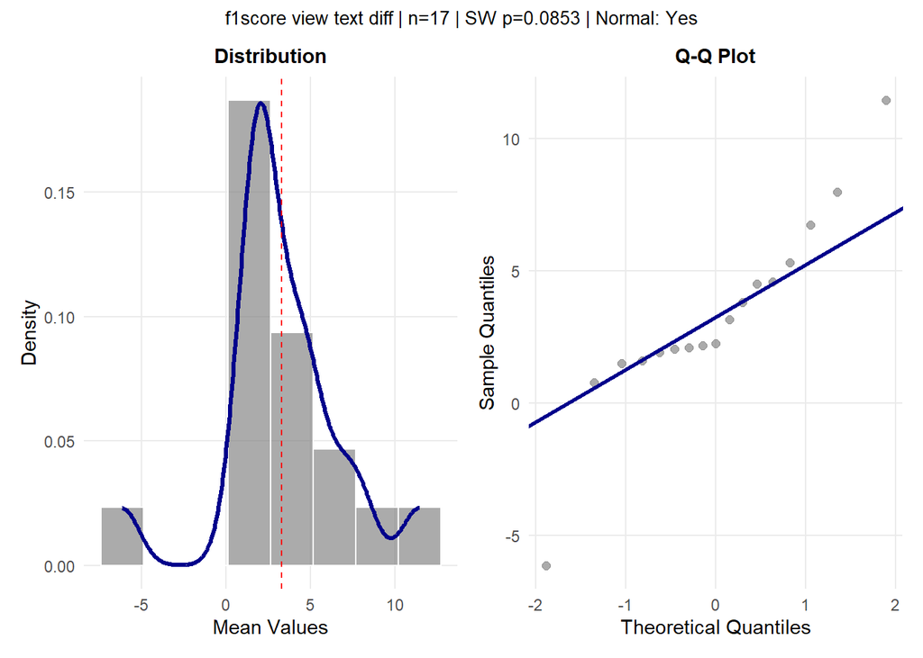

```r
global_palette <- stats::setNames(
  grDevices::colorRampPalette(ggsci::pal_jco("default")(4))(4),
  unique(histogram_data$Metric)
)

create_normality_plots(histogram_data, 'f1score_view_text_diff', global_palette)
```

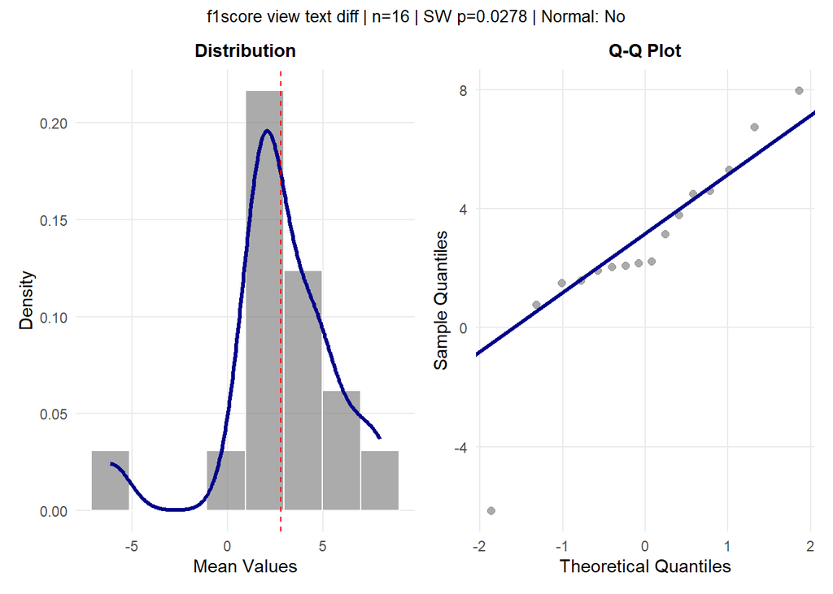

```r
global_palette <- stats::setNames(
  grDevices::colorRampPalette(ggsci::pal_jco("default")(4))(4),
  unique(histogram_data$Metric)
)

create_normality_plots(histogram_data %>% filter(!(bibtex %in% c('bhatt2019', 'aminim2009'))), 'f1score_view_text_diff', global_palette)
```

```r
knitr::kable(histogram_data %>% filter(statistic  == 'Mean') %>% group_by(.data[['Metric']])  %>%  filter(Metric == 'f1score_view_text_diff'), caption = "Distribution of extracted indicators values per papers") %>% kableExtra::kable_styling()
```

Table 3.31: Table 3.32: Distribution of extracted indicators values per papers

| bibtex | Metric | statistic | value |
| --- | --- | --- | --- |
| aminim2009 | f1score_view_text_diff | Mean | 11.466667 |
| aminim2010 | f1score_view_text_diff | Mean | 2.243750 |
| aminim2010b | f1score_view_text_diff | Mean | 7.983333 |
| carmona2020 | f1score_view_text_diff | Mean | 1.500000 |
| fakri2015 | f1score_view_text_diff | Mean | 5.325000 |
| fengz2024 | f1score_view_text_diff | Mean | 1.923333 |
| ghorbanali2024 | f1score_view_text_diff | Mean | -6.150000 |
| graffm2023 | f1score_view_text_diff | Mean | 0.770000 |
| gui2021 | f1score_view_text_diff | Mean | 3.800000 |
| guptad2018 | f1score_view_text_diff | Mean | 2.040000 |
| huz2017 | f1score_view_text_diff | Mean | 4.600000 |
| iglesias2016 | f1score_view_text_diff | Mean | 1.600000 |
| jiz2024 | f1score_view_text_diff | Mean | 2.172000 |
| karisanip2022 | f1score_view_text_diff | Mean | 4.500000 |
| liuw2021 | f1score_view_text_diff | Mean | 6.753333 |
| luox2022 | f1score_view_text_diff | Mean | 3.160000 |
| zhangx2010b | f1score_view_text_diff | Mean | 2.100000 |

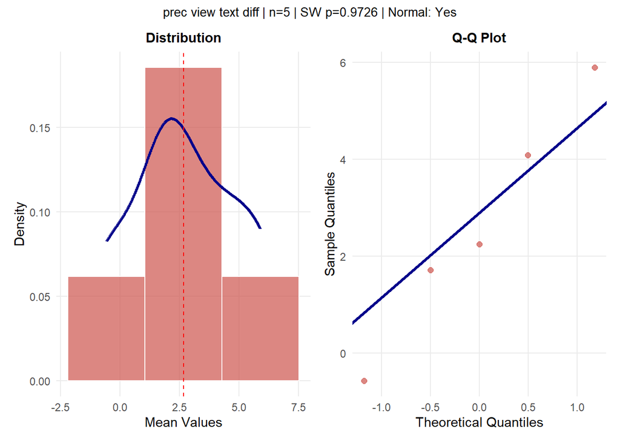

```r
global_palette <- stats::setNames(
  grDevices::colorRampPalette(ggsci::pal_jco("default")(4))(4),
  unique(histogram_data$Metric)
)

create_normality_plots(histogram_data, 'prec_view_text_diff', global_palette)
```

```r
knitr::kable(histogram_data %>% filter(statistic  == 'Mean') %>% group_by(.data[['Metric']])  %>%  filter(Metric == 'prec_view_text_diff'), caption = "Distribution of extracted indicators values per papers") %>% kableExtra::kable_styling()
```

Table 3.33: Table 3.34: Distribution of extracted indicators values per papers

| bibtex | Metric | statistic | value |
| --- | --- | --- | --- |
| chens2019 | prec_view_text_diff | Mean | 1.720833 |
| dasigiv2001 | prec_view_text_diff | Mean | -0.567500 |
| huz2017 | prec_view_text_diff | Mean | 5.900000 |
| karisanip2022 | prec_view_text_diff | Mean | 2.250000 |
| liuw2021 | prec_view_text_diff | Mean | 4.086667 |

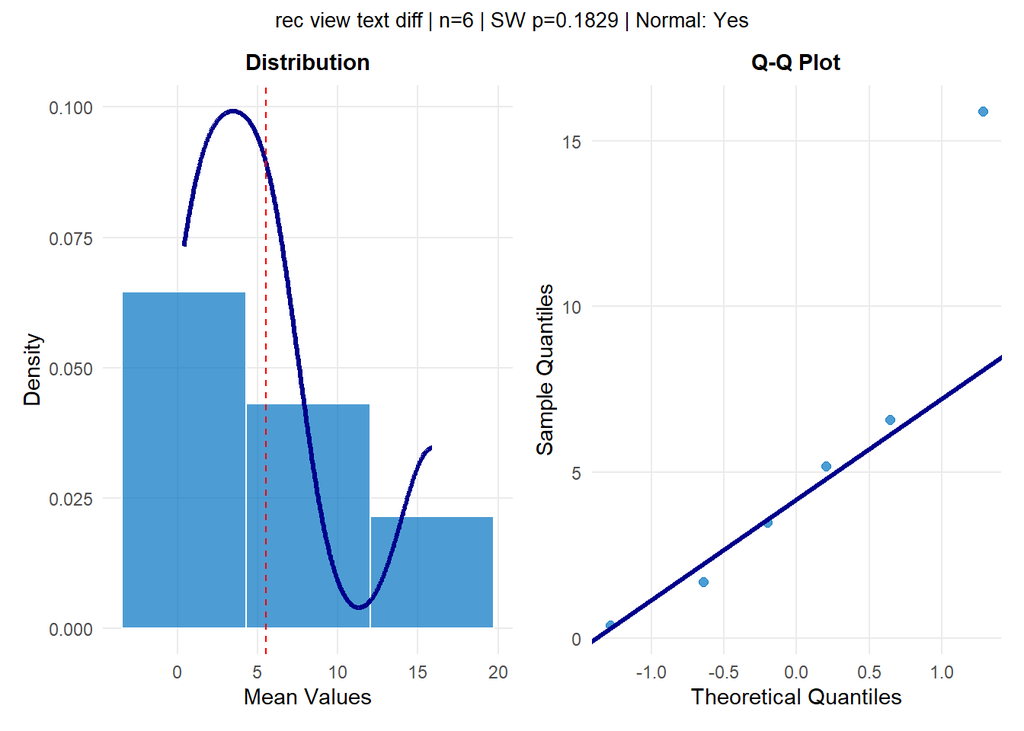

```r
global_palette <- stats::setNames(
  grDevices::colorRampPalette(ggsci::pal_jco("default")(4))(4),
  unique(histogram_data$Metric)
)

create_normality_plots(histogram_data, 'rec_view_text_diff', global_palette)
```

```r
knitr::kable(histogram_data %>% filter(statistic  == 'Mean') %>% group_by(.data[['Metric']])  %>%  filter(Metric == 'rec_view_text_diff'), caption = "Distribution of extracted indicators values per papers") %>% kableExtra::kable_styling()
```

Table 3.35: Table 3.36: Distribution of extracted indicators values per papers

| bibtex | Metric | statistic | value |
| --- | --- | --- | --- |
| akhtiamov2019 | rec_view_text_diff | Mean | 0.400000 |
| dasigiv2001 | rec_view_text_diff | Mean | 15.887500 |
| gui2021 | rec_view_text_diff | Mean | 3.500000 |
| huz2017 | rec_view_text_diff | Mean | 1.700000 |
| karisanip2022 | rec_view_text_diff | Mean | 5.200000 |
| liuw2021 | rec_view_text_diff | Mean | 6.593333 |

Global statistics mean of means and median of medians.

```r
# Create summary statistics grouped by Metric and statistic
histogram_summary <- histogram_data %>%
  group_by(.data[['Metric']], .data[['statistic']]) %>%
  summarise(
    summary_stats_grouped(value),
    .groups = "drop"
  )

knitr::kable(histogram_summary,
             caption = "Summary Statistics of Mean and Median Fifferences Values by Metric.",
             digits = 3) %>%
  kableExtra::kable_styling(bootstrap_options = c("striped", "hover")) %>%
  kableExtra::collapse_rows(columns = 1, valign = "top")
```

Table 3.37: Table 3.38: Summary Statistics of Mean and Median Fifferences Values by Metric.

| Metric | statistic | Count | Min | Q1 | Median | Mean | Q3 | Max | SD |
| --- | --- | --- | --- | --- | --- | --- | --- | --- | --- |
| acc_view_text_diff | Mean | 20 | -0.205 | 1.465 | 2.137 | 4.340 | 5.294 | 26.990 | 5.987 |
|  | Median | 20 | -0.205 | 1.258 | 2.349 | 4.285 | 5.294 | 26.990 | 5.985 |
| f1score_view_text_diff | Mean | 17 | -6.150 | 1.923 | 2.244 | 3.282 | 4.600 | 11.467 | 3.684 |
|  | Median | 17 | -6.150 | 2.000 | 2.640 | 3.198 | 4.500 | 12.200 | 3.751 |
| prec_view_text_diff | Mean | 5 | -0.568 | 1.721 | 2.250 | 2.678 | 4.087 | 5.900 | 2.449 |
|  | Median | 5 | -1.590 | 1.520 | 2.250 | 2.384 | 3.840 | 5.900 | 2.786 |
| rec_view_text_diff | Mean | 6 | 0.400 | 2.150 | 4.350 | 5.547 | 6.245 | 15.887 | 5.543 |
|  | Median | 6 | 0.400 | 2.150 | 4.350 | 5.494 | 6.003 | 15.895 | 5.535 |

Prepare table to article

```r
clean_data <- preprocess_for_plotting(histogram_data)

summary_table_data <- clean_data %>%
  group_by(Metric, statistic) %>%
  summarise(
    N = n(),
    Min = min(Difference, na.rm = TRUE),
    Q1 = quantile(Difference, 0.25, na.rm = TRUE),
    Median = median(Difference, na.rm = TRUE),
    Mean = mean(Difference, na.rm = TRUE),
    Q3 = quantile(Difference, 0.75, na.rm = TRUE),
    Max = max(Difference, na.rm = TRUE),
    SD = sd(Difference, na.rm = TRUE),
    .groups = "drop" # Ungroup after summarising
  ) %>%
  # Arrange for better readability
  arrange(Metric, statistic)
```

```r
knitr::kable(summary_table_data,
             caption = "Descriptive Statistics for Study-Level Performance Differences.",
             digits = 3) %>%
  kableExtra::kable_styling(bootstrap_options = c("striped", "hover")) %>%
  kableExtra::collapse_rows(columns = 1, valign = "top")
```

Table 3.39: Table 3.40: Descriptive Statistics for Study-Level Performance Differences.

| Metric | statistic | N | Min | Q1 | Median | Mean | Q3 | Max | SD |
| --- | --- | --- | --- | --- | --- | --- | --- | --- | --- |
| Accuracy | Mean | 20 | -0.205 | 1.465 | 2.137 | 4.340 | 5.294 | 26.990 | 5.987 |
|  | Median | 20 | -0.205 | 1.258 | 2.349 | 4.285 | 5.294 | 26.990 | 5.985 |
| F1 Score | Mean | 17 | -6.150 | 1.923 | 2.244 | 3.282 | 4.600 | 11.467 | 3.684 |
|  | Median | 17 | -6.150 | 2.000 | 2.640 | 3.198 | 4.500 | 12.200 | 3.751 |
| Precision | Mean | 5 | -0.568 | 1.721 | 2.250 | 2.678 | 4.087 | 5.900 | 2.449 |
|  | Median | 5 | -1.590 | 1.520 | 2.250 | 2.384 | 3.840 | 5.900 | 2.786 |
| Recall | Mean | 6 | 0.400 | 2.150 | 4.350 | 5.547 | 6.245 | 15.887 | 5.543 |
|  | Median | 6 | 0.400 | 2.150 | 4.350 | 5.494 | 6.003 | 15.895 | 5.535 |

```r
latex_table_code <- summary_table_data %>%
  # Use kable() with formatting for LaTeX
  kable(
    format = "latex",
    booktabs = TRUE, # Creates professional horizontal lines (\toprule, \midrule, etc.)
    digits = 2,      # Round all numbers to 2 decimal places
    caption = "Descriptive Statistics for Study-Level Performance Differences.",
    label = "tab:summary_stats", # For referencing in text with \ref{tab:summary_stats}
    col.names = c("Metric", "Stat.", "N", "Min", "Q1", "Median", "Mean", "Q3", "Max", "SD")
  ) %>%
  # Use kable_styling for a better look
  kable_styling(latex_options = c("striped", "scale_down")) %>%
  # Group rows by Metric for excellent readability
  group_rows(index = table(summary_table_data$Metric))

# Print the code to the console
print(latex_table_code)
```

```
## \begin{table}
## \centering
## \caption{(\#tab:tab:summary_stats)Descriptive Statistics for Study-Level Performance Differences.}
## \centering
## \resizebox{\ifdim\width>\linewidth\linewidth\else\width\fi}{!}{
## \begin{tabular}[t]{llrrrrrrrr}
## \toprule
## Metric & Stat. & N & Min & Q1 & Median & Mean & Q3 & Max & SD\\
## \midrule
## \addlinespace[0.3em]
## \multicolumn{10}{l}{\textbf{Accuracy}}\\
## \hspace{1em}\cellcolor{gray!10}{Accuracy} & \cellcolor{gray!10}{Mean} & \cellcolor{gray!10}{20} & \cellcolor{gray!10}{-0.20} & \cellcolor{gray!10}{1.46} & \cellcolor{gray!10}{2.14} & \cellcolor{gray!10}{4.34} & \cellcolor{gray!10}{5.29} & \cellcolor{gray!10}{26.99} & \cellcolor{gray!10}{5.99}\\
## \hspace{1em}Accuracy & Median & 20 & -0.20 & 1.26 & 2.35 & 4.28 & 5.29 & 26.99 & 5.98\\
## \addlinespace[0.3em]
## \multicolumn{10}{l}{\textbf{F1 Score}}\\
## \hspace{1em}\cellcolor{gray!10}{F1 Score} & \cellcolor{gray!10}{Mean} & \cellcolor{gray!10}{17} & \cellcolor{gray!10}{-6.15} & \cellcolor{gray!10}{1.92} & \cellcolor{gray!10}{2.24} & \cellcolor{gray!10}{3.28} & \cellcolor{gray!10}{4.60} & \cellcolor{gray!10}{11.47} & \cellcolor{gray!10}{3.68}\\
## \hspace{1em}F1 Score & Median & 17 & -6.15 & 2.00 & 2.64 & 3.20 & 4.50 & 12.20 & 3.75\\
## \addlinespace[0.3em]
## \multicolumn{10}{l}{\textbf{Precision}}\\
## \hspace{1em}\cellcolor{gray!10}{Precision} & \cellcolor{gray!10}{Mean} & \cellcolor{gray!10}{5} & \cellcolor{gray!10}{-0.57} & \cellcolor{gray!10}{1.72} & \cellcolor{gray!10}{2.25} & \cellcolor{gray!10}{2.68} & \cellcolor{gray!10}{4.09} & \cellcolor{gray!10}{5.90} & \cellcolor{gray!10}{2.45}\\
## \hspace{1em}Precision & Median & 5 & -1.59 & 1.52 & 2.25 & 2.38 & 3.84 & 5.90 & 2.79\\
## \addlinespace[0.3em]
## \multicolumn{10}{l}{\textbf{Recall}}\\
## \hspace{1em}\cellcolor{gray!10}{Recall} & \cellcolor{gray!10}{Mean} & \cellcolor{gray!10}{6} & \cellcolor{gray!10}{0.40} & \cellcolor{gray!10}{2.15} & \cellcolor{gray!10}{4.35} & \cellcolor{gray!10}{5.55} & \cellcolor{gray!10}{6.24} & \cellcolor{gray!10}{15.89} & \cellcolor{gray!10}{5.54}\\
## \hspace{1em}Recall & Median & 6 & 0.40 & 2.15 & 4.35 & 5.49 & 6.00 & 15.89 & 5.54\\
## \bottomrule
## \end{tabular}}
## \end{table}
```

Our choice of statistical tests was guided by a formal assessment of the assumptions underlying parametric testing, specifically data distribution and sample size. The analysis was conducted on the paired differences between the multi-view and single-view approaches for each performance metric.

1. Data Assessment and Assumption Checking

An initial analysis was conducted using descriptive statistics, data visualization, and formal normality testing.

Sample Sizes: The number of paired comparisons available for analysis was moderate for accuracy (n=20) and F1-score (n=17), but critically small for precision (n=5) and recall (n=6).

Normality of Differences: The Shapiro-Wilk test for normality was applied to the distribution of the paired differences for each metric. The test rejected the null hypothesis of normality for accuracy (p < 0.05) but failed to reject it for F1-score, precision, and recall (p > 0.05). An outlier was also identified in the accuracy data.

2. Rationale for Non-Parametric Testing and Methodological Limitations

The violation of the normality assumption for the accuracy metric precludes the use of a standard paired t-test. For the F1-score, precision, and recall metrics, while normality was not rejected, this finding must be interpreted with extreme caution. Normality tests have very low statistical power on small samples (n < 30) and are particularly unreliable for the precision (n=5) and recall (n=6) samples.

Given these conditions, the sample size itself, rather than the unprovable nature of the distribution, becomes the primary reason for avoiding parametric tests. No statistical test can compensate for the low power and high uncertainty inherent in such small samples.

Therefore, we have adopted a non-parametric testing strategy. The results for precision and recall should be considered exploratory and interpreted with significant caution, as the small sample sizes prevent robust statistical inference.

3. Statistical Tests for Research Questions

To provide a comprehensive comparison, we address the our research questions. By employing both a permutation test for the mean and a Wilcoxon signed-rank test for the central tendency, we provide a multi-faceted and robust comparison, while acknowledging the inherent limitations of our dataset.

### 3.3.2 Inferential Testing Across Studies: Statistical tests of the difference in the distributions of metrics values

#### 3.3.2.1 Permutation test

```r
# Define metrics from histogram_data
metrics <- unique(histogram_data$Metric)

# Run the permutation test for each metric
all_perm_stats <- t(sapply(metrics, get_permutation_stats, data = histogram_data))

# Convert to a data frame for nice formatting
results_perm <- data.frame(
  metric = metrics,
  all_perm_stats,
  significant = ifelse(!is.na(all_perm_stats[, "p_value"]) & all_perm_stats[, "p_value"] < 0.05, "Yes", "No"),
  stars = ifelse(
    is.na(all_perm_stats[, "p_value"]), "NA",
    ifelse(all_perm_stats[, "p_value"] < 0.001, "***",
    ifelse(all_perm_stats[, "p_value"] < 0.01, "**",
    ifelse(all_perm_stats[, "p_value"] < 0.05, "*", "ns")))
  ),
  effect = ifelse(
    is.na(all_perm_stats[, "cohens_d"]), "NA",
    # Interpretation for Cohen's d
    # Note: we use abs() for magnitude regardless of direction
    ifelse(abs(all_perm_stats[, "cohens_d"]) < 0.2, "Negligible",
    ifelse(abs(all_perm_stats[, "cohens_d"]) < 0.5, "Small",
    ifelse(abs(all_perm_stats[, "cohens_d"]) < 0.8, "Medium", "Large")))
  )
)

rownames(results_perm) <- NULL
```

```r
knitr::kable(results_perm,
             caption = "Permutation test - Testing if mean differences differ from zero.",
             col.names = c("Metric", "Observed Mean", "p-value", "Cohen's d", "n", "Significant (p<0.05)", " ", "Effect Size"),
             digits = 3) %>%
  kableExtra::kable_styling(bootstrap_options = "striped", full_width = FALSE)
```

Table 3.41: Table 3.42: Permutation test - Testing if mean differences differ from zero.

Metric

Observed Mean

p-value

Cohen’s d

n

Significant (p<0.05)

Effect Size

rec_view_text_diff

5.547

0.032

1.001

6

Yes

Large

acc_view_text_diff

4.340

0.000

0.725

20

Yes

***

Medium

f1score_view_text_diff

3.282

0.002

0.891

17

Yes

Large

prec_view_text_diff

2.678

0.129

1.093

5

No

ns

Large

To evaluate the impact of the multi-view approach on mean performance, a one-sample permutation test (9,999 permutations) was conducted on the paired differences for each metric. The results, demonstrate a clear and consistent advantage for the multi-view methodology.

The analysis revealed a statistically significant improvement for the multi-view approach in terms of accuracy. The mean difference was 4.34 points in favor of the multi-view method, a result that was highly unlikely to be due to chance (p = 0.0001). This was supported by a medium, practically meaningful effect size (Cohen’s d = 0.73). An even larger, significant improvement was observed for F1-score, which increased by an average of 3.28 points (p = 0.0019) with a large effect size (Cohen’s d = 0.89).

Notably, despite the small sample size (n=6), a statistically significant improvement was also found for recall (mean increase = 5.55, p = 0.0316). The large effect size (Cohen’s d = 1.00) and statistical significance suggest that the positive impact on recall was very consistent across the available data points.

In contrast, the test for precision did not yield a statistically significant result (p = 0.13). Although the observed effect in the sample was large (Cohen’s d = 1.09), the extremely small sample size (n=5) leads to low statistical power and high uncertainty. Therefore, we cannot draw a reliable conclusion about the effect of the multi-view approach on precision, and this finding should be considered inconclusive.

In summary, the permutation test provides robust evidence that the multi-view approach significantly enhances mean accuracy, F1-score, and recall. The evidence regarding its impact on precision is inconclusive, likely due to data limitations.

#### 3.3.2.2 Wilcoxon signed-rank test and effect size r (rank-biserial correlation)

Rank-Biserial Correlation (r) is the effect size for the Wilcoxon test. For a paired test (Wilcoxon Signed-Rank), it’s calculated from the sum of signed ranks. In simple words, It answers the question:

- How strong and consistent is the direction of the difference, weighting by the size of the rank? It also ranges from -1 to 1.

```r
metrics <- unique(histogram_data$Metric)

# Get all test results using the function
all_stats_corrected <- t(sapply(metrics, get_wilcox_stats_corrected, data = histogram_data))

# Convert to data frame and add interpretations
results_corrected <- data.frame(
  metric = metrics,
  all_stats_corrected,
  significant = ifelse(!is.na(all_stats_corrected[, "p"]) & all_stats_corrected[, "p"] < 0.05, "Yes", "No"),
  stars = ifelse(is.na(all_stats_corrected[, "p"]), "NA",
                 ifelse(all_stats_corrected[, "p"] < 0.001, "***",
                 ifelse(all_stats_corrected[, "p"] < 0.01, "**",
                 ifelse(all_stats_corrected[, "p"] < 0.05, "*", "ns")))),
  effect = ifelse(is.na(all_stats_corrected[, "r"]), "NA",
                  ifelse(abs(all_stats_corrected[, "r"]) < 0.1, "Negligible",
                  ifelse(abs(all_stats_corrected[, "r"]) < 0.3, "Small",
                  ifelse(abs(all_stats_corrected[, "r"]) < 0.5, "Medium", "Large"))))
)


rownames(results_corrected) <- NULL
```

```r
# Create formatted table
knitr::kable(results_corrected,
             caption = "Wilcoxon signed-rank test - Testing if mean differences differ from zero",
             digits = 4) %>%
  kableExtra::kable_styling()
```

Table 3.43: Table 3.44: Wilcoxon signed-rank test - Testing if mean differences differ from zero

metric

V

p

r

n

CI

CI_Lower

CI_Upper

Mean_Difference

Median_Difference

significant

stars

effect

rec_view_text_diff

21

0.0313

1.0000

6

0.95

1.0000

1.0000

5.5468

4.3500

Yes

Large

acc_view_text_diff

209

0.0000

0.9905

20

0.95

0.9743

0.9965

4.3405

2.1371

Yes

***

Large

f1score_view_text_diff

139

0.0017

0.8170

17

0.95

0.5416

0.9340

3.2816

2.2438

Yes

Large

prec_view_text_diff

14

0.1250

0.8667

5

0.95

0.3368

0.9796

2.6780

2.2500

No

ns

Large

To address our second research question and to assess the robustness of our findings to potential outliers, we conducted a Wilcoxon signed-rank test. This test evaluates the central tendency (median) of the paired differences. The results strongly corroborate the findings from the permutation test.

The analysis revealed a highly significant positive difference in the central tendency for accuracy (V = 209, p < .001) and F1-score (V = 139, p = .002). This confirms that the advantage of the multi-view approach for these metrics is not merely an artifact of the mean being skewed by extreme values but represents a consistent, positive shift in typical performance.

A statistically significant positive difference was also found for recall (V = 21, p = .031). As with the permutation test, this result, while significant, is based on a small sample (n=6) and should be interpreted as indicative but less robust than the findings for accuracy and F1-score.

For precision, the Wilcoxon test found no statistically significant evidence of a difference (V = 14, p = 0.125), a result consistent with the underpowered permutation test. This reinforces the conclusion that the data is insufficient to make a reliable claim about the impact on precision.

A Note on Effect Size (r): It is important to note that while the calculated rank-biserial correlation (r) suggests a “Large” effect for all metrics, this effect size measure can be misleading when sample sizes are critically small. For the precision metric, the non-significant p-value tells us we cannot confidently conclude the effect is different from zero, rendering the large r value an unreliable indicator of practical importance. Therefore, the primary conclusion is drawn from the p-value, which properly accounts for sample size and statistical uncertainty.

#### 3.3.2.3 Calculate Cliff’s Delta

Cliff’s Delta (d) is an effect size of dominance. It answers the question:

- If I pick a random value from group A and a random value from group B, what is the probability that the value from A is larger, minus the probability that the value from B is larger? (It ranges from -1 to 1)

```r
# Define the metrics
metrics <- c("acc", "prec", "rec", "f1score")

# Initialize data frame to store results
cliff_summary <- data.frame(
  Metric = character(),
  Delta = numeric(),
  CI_Lower = numeric(),
  CI_Upper = numeric(),
  Magnitude = character(),
  N = integer(),
  Mean_Single = numeric(),
  Mean_Combo = numeric(),
  stringsAsFactors = FALSE
)

# Calculate Cliff's Delta for each metric
for (metric in metrics) {
  # Prepare data for this metric
  cliff_data <- prepare_cliff_data(metric, data_clean, aggregation_method = "mean")

  # Skip if no valid data
  if (is.null(cliff_data) || nrow(cliff_data) < 3) {
    next
  }

  # Calculate Cliff's Delta (combinations vs single)
  result <- cliff.delta(cliff_data$combo_view, cliff_data$single_view, paired = TRUE)

  # Add to summary data frame
  cliff_summary <- rbind(
    cliff_summary,
    data.frame(
      Metric = metric,
      Delta = result$estimate,
      CI_Lower = result$conf.int[1],
      CI_Upper = result$conf.int[2],
      Magnitude = result$magnitude,
      N = nrow(cliff_data),
      Mean_Single = mean(cliff_data$single_view),
      Mean_Combo = mean(cliff_data$combo_view),
      Mean_Difference = mean(cliff_data$combo_view)-mean(cliff_data$single_view),
      stringsAsFactors = FALSE
    )
  )
}

rownames(cliff_summary) <- NULL
```

```r
knitr::kable(cliff_summary,
             caption = "Cliff's Delta - Effect Size for Combinations vs Single View (Levels: negligible < small < medium < large)",
             digits = 4) %>%
  kableExtra::kable_styling()
```

Table 3.45: Table 3.46: Cliff’s Delta - Effect Size for Combinations vs Single View (Levels: negligible < small < medium < large)

| Metric | Delta | CI_Lower | CI_Upper | Magnitude | N | Mean_Single | Mean_Combo | Mean_Difference |
| --- | --- | --- | --- | --- | --- | --- | --- | --- |
| acc | 0.2200 | -0.1520 | 0.5374 | small | 20 | 77.6143 | 81.9548 | 4.3405 |
| prec | 0.1200 | -0.6060 | 0.7369 | negligible | 5 | 74.1510 | 76.8290 | 2.6780 |
| rec | 0.2222 | -0.4664 | 0.7431 | small | 6 | 69.4415 | 74.9883 | 5.5468 |
| f1score | 0.1626 | -0.2382 | 0.5161 | small | 17 | 72.8297 | 76.1113 | 3.2816 |

```r
# Print formatted results
cat("\nCliff's Delta Effect Size Results (Combinations vs Single View):\n")
```

```
##
## Cliff's Delta Effect Size Results (Combinations vs Single View):
```

```r
cat("================================================================\n")
for (i in 1:nrow(cliff_summary)) {
  row <- cliff_summary[i, ]
  cat(
    sprintf(
      "\n%s: δ = %.4f (95%% CI: %.4f to %.4f), %s effect, n = %d\n",
      toupper(row$Metric),
      row$Delta,
      row$CI_Lower,
      row$CI_Upper,
      row$Magnitude,
      row$N
    )
  )
  cat(sprintf("  Mean Single View: %.2f, Mean Combinations: %.2f\n",
              row$Mean_Single, row$Mean_Combo))
}
```

```
##
## ACC: d = 0.2200 (95% CI: -0.1520 to 0.5374), small effect, n = 20
##   Mean Single View: 77.61, Mean Combinations: 81.95
##
## PREC: d = 0.1200 (95% CI: -0.6060 to 0.7369), negligible effect, n = 5
##   Mean Single View: 74.15, Mean Combinations: 76.83
##
## REC: d = 0.2222 (95% CI: -0.4664 to 0.7431), small effect, n = 6
##   Mean Single View: 69.44, Mean Combinations: 74.99
##
## F1SCORE: d = 0.1626 (95% CI: -0.2382 to 0.5161), small effect, n = 17
##   Mean Single View: 72.83, Mean Combinations: 76.11
```

It’s important to understand what Cliff’s Delta tells us. It is a non-parametric effect size that measures stochastic dominance.

A Delta of 0.22 (for Accuracy) means that if we randomly select a study, there is a 22% higher probability that the multi-view approach had a better result than the single-view approach than the reverse.

A Delta of 0 means it’s a 50/50 chance which one is better.

The Confidence Interval (CI) is the most important part for inference. A 95% CI that does not cross zero suggests we are 95% confident that a real effect exists. A CI that does cross zero means we cannot rule out the possibility of zero (or even a negative) effect.

1. Accuracy (acc)
- Delta (0.220): This is a small positive effect. It suggests a consistent, albeit modest, advantage for the multi-view approach.
- CI [-0.15, 0.54]: This is the key finding. The confidence interval is wide and crosses zero.
- Interpretation: This does not contradict our significant p-value from the other tests. It adds nuance. The p-value told us “the effect is probably not zero.” This CI tells us “…but given the sample size (n=20) and variability, the true effect could plausibly range from a small negative effect (-15%) to a large positive one (+54%).” It highlights our uncertainty about the effect’s magnitude.
2. F1-Score (f1score)
- Delta (0.163): A small positive effect, similar to accuracy.
- CI [-0.24, 0.52]: Again, this CI is wide and crosses zero.
- Interpretation: The conclusion is the same as for accuracy. There is evidence of a small, positive effect, but we cannot be highly confident in its precise size.
3. Recall (rec)
- Delta (0.222): A small positive effect, consistent with the other metrics.
- CI [-0.47, 0.74]: This interval is extremely wide, spanning from a substantial negative effect to a very large positive one.
- Interpretation: This is a classic signature of an underpowered analysis (n=6). The CI correctly reflects that while the point estimate is positive, the data is far too limited to make any confident claim about the size or even the direction of the true effect.
4. Precision (prec)
- Delta (0.120): A negligible effect.
- CI [-0.61, 0.74]: An even wider confidence interval due to the critically small sample (n=5).
- Interpretation: The results for precision are entirely inconclusive. The CI tells the true story: we know very little about the effect of the multi-view approach on precision from this data.

### 3.3.3 Discussion

To quantify the practical magnitude of the difference between the two approaches, we calculated Cliff’s Delta, a non-parametric effect size. This metric evaluates the probability that a randomly selected outcome from a multi-view study is superior to that of a single-view study.

The analysis showed a small, positive effect size for accuracy (Delta = 0.22), F1-score (Delta = 0.16), and recall (Delta = 0.22). The effect for precision was negligible (Delta = 0.12). These point estimates suggest a consistent, modest advantage for the multi-view approach across most metrics.

Crucially, however, the 95% confidence intervals for the Delta statistic were wide for all metrics and all of them included zero. For example, the CI for accuracy was [-0.15, 0.54]. This does not contradict our earlier findings of statistical significance; rather, it provides important context. While the permutation and Wilcoxon tests indicate that an effect is likely present (p < 0.05), the Cliff’s Delta confidence intervals reveal that there is considerable uncertainty about the true magnitude of this effect. The wide CIs for recall and precision, in particular, highlight that the analysis for these metrics is severely underpowered.

Taken together, our three analyses tell a comprehensive and nuanced story. The permutation and Wilcoxon tests provide strong evidence that a statistically detectable positive effect exists for Accuracy, F1-Score, and Recall. The Cliff’s Delta analysis complements this by clarifying that the practical magnitude of this effect is likely small, and our ability to precisely estimate its size is limited by the sample sizes. Therefore, we conclude that the literature provides evidence for a consistent but modest advantage when using a multi-view approach.

## 3.4 Meta-analysis: A deeper insight analysis

Our meta-analysis has a small number of studies (from k=5 to k=20). Standard meta-analysis methods can be overly optimistic in this situation, underestimating the true uncertainty. The `clubSandwich` package (`robust()`) corrects for this by providing more conservative and trustworthy p-values and confidence intervals. Using the `robust()` results demonstrates that we have used state-of-the-art, appropriate methods for our data, which makes our conclusions far more defensible.

In our analysis, we:

- Prioritize the RVE results.
- Lead with the Weighted RVE model. This is our best and most defensible estimate of the true effect.
- Follow with the Unweighted RVE model. Use this to prove that our main finding is robust.
- Present the non-RVE results as a point of comparison. We present non-RVE results to show what we would have found using older, less appropriate methods. Their main purpose is to be transparent and, in this case, to demonstrate why the robust corrections were necessary.

This report will perform the same meta-analysis for four key metrics: Accuracy, F1-Score, Precision, and Recall.

```r
metrics_to_analyze <- list(
  list(comb = "acc.view.combinations.text", single = "acc.view.single.text", name = "Accuracy"),
  list(comb = "f1score.view.combinations.text", single = "f1score.view.single.text", name = "F1-Score"),
  list(comb = "prec.view.combinations.text", single = "prec.view.single.text", name = "Precision"),
  list(comb = "rec.view.combinations.text", single = "rec.view.single.text", name = "Recall")
)

all_results <- list()

for (metric in metrics_to_analyze) {
  all_results[[metric$name]] <- perform_meta_analysis(
    raw_data_frame = data_filled,
    col_comb = metric$comb,
    col_single = metric$single,
    metric_name = metric$name
  )
}
```

### 3.4.1 Publication bias analysis

```r
metric_names <- names(all_results) # e.g., "Accuracy", "F1-Score", "Precision", "Recall"
print(metric_names)
```

```
## [1] "Accuracy"  "F1-Score"  "Precision" "Recall"
```

```r
name <- "Accuracy"
check_publication_bias(all_results[[name]], name)
```

```
##
## ==============================================
## PUBLICATION BIAS ANALYSIS: Accuracy (k=20)
## ==============================================
```

```
## [File saved]: Funnel plot saved to fig-mv-funnel-accuracy.pdf
```

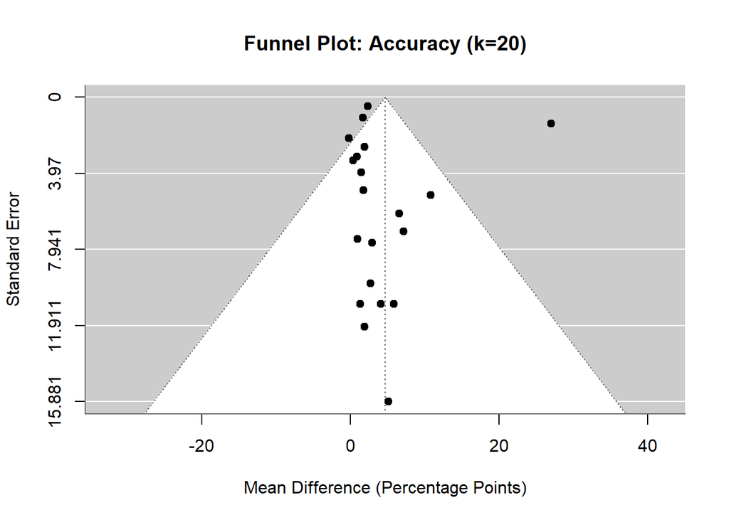

```
##
## Egger's Regression Test Results:
##
## Regression Test for Funnel Plot Asymmetry
##
## Model:     mixed-effects meta-regression model
## Predictor: standard error
##
## Test for Funnel Plot Asymmetry: z = -0.4309, p = 0.6665
## Limit Estimate (as sei -> 0):   b =  5.8206 (CI: -0.7540, 12.3951)
##
## --> Result: No significant asymmetry detected (p >= 0.05).
```

```r
name <- "F1-Score"
check_publication_bias(all_results[[name]], name)
```

```
##
## ==============================================
## PUBLICATION BIAS ANALYSIS: F1-Score (k=17)
## ==============================================
```

```
## [File saved]: Funnel plot saved to fig-mv-funnel-f1-score.pdf
```

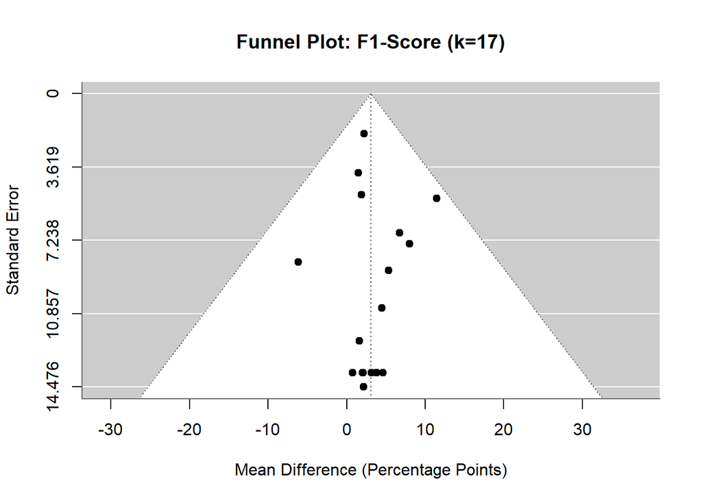

```
##
## Egger's Regression Test Results:
##
## Regression Test for Funnel Plot Asymmetry
##
## Model:     mixed-effects meta-regression model
## Predictor: standard error
##
## Test for Funnel Plot Asymmetry: z = 0.2803, p = 0.7793
## Limit Estimate (as sei -> 0):   b = 2.5749 (CI: -1.9052, 7.0550)
##
## --> Result: No significant asymmetry detected (p >= 0.05).
```

```r
name <- "Precision"
check_publication_bias(all_results[[name]], name)
```

```
##
## ==============================================
## PUBLICATION BIAS ANALYSIS: Precision (k=5)
## ==============================================
## Skipping formal tests: Too few studies (k < 10) for reliable bias detection.
```

```r
name <- "Recall"
check_publication_bias(all_results[[name]], name)
```

```
##
## ==============================================
## PUBLICATION BIAS ANALYSIS: Recall (k=6)
## ==============================================
## Skipping formal tests: Too few studies (k < 10) for reliable bias detection.
```

### 3.4.2 Standard (Inverse-Variance Weighted) Random-Effects Model (Gold Standard)

This model answers the question:

- What is the average effect if we give more weight to studies that provide more precise estimates (i.e., larger n, smaller sd)?

This is the standard approach. To do this, we need to handle the studies with n=1. The best practice is data imputation: we will “fill in” a reasonable estimate for the missing standard deviations.

#### 3.4.2.1 Weighted Random-Effects Model: Accuracy

```r
print("--- Weighted Model (All studies equal): Accuracy ---")
```

```
## [1] "--- Weighted Model (All studies equal): Accuracy ---"
```

```r
summary(all_results$Accuracy$weighted_rve)
```

```
##
## Random-Effects Model (k = 20; tau^2 estimator: REML)
##
##   logLik  deviance       AIC       BIC      AICc
## -66.5922  133.1844  137.1844  139.0733  137.9344
##
## tau^2 (estimated amount of total heterogeneity): 48.9036 (SE = 24.2254)
## tau (square root of estimated tau^2 value):      6.9931
## I^2 (total heterogeneity / total variability):   90.20%
## H^2 (total variability / sampling variability):  10.21
##
## Test for Heterogeneity:
## Q(df = 19) = 302.4905, p-val < .0001
##
## Number of estimates:   20
## Number of clusters:    20
## Estimates per cluster: 1
##
## Model Results:
##
## estimate      se¹    tval¹     df¹    pval¹   ci.lb¹   ci.ub¹
##   4.6748  2.0275   2.3057   15.72   0.0351   0.3704   8.9793   *
##
## ---
## Signif. codes:  0 '***' 0.001 '**' 0.01 '*' 0.05 '.' 0.1 ' ' 1
##
## 1) results based on cluster-robust inference (var-cov estimator: CR2,
##    approx t-test and confidence interval, df: Satterthwaite approx)
```

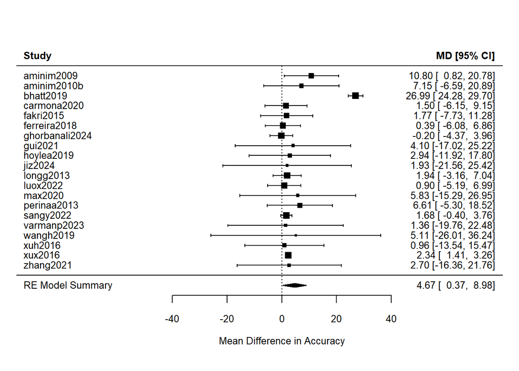

```r
forest(all_results$Accuracy$weighted_rve,
       slab = all_results$Accuracy$effect_sizes$studylab,
       header = "Study",
       xlab = "Mean Difference in Accuracy",
       mlab = "RE Model Summary",
       cex = 0.8)
```

```r
print("--- Weighted Model (All studies equal): Accuracy ---")
```

```
## [1] "--- Weighted Model (All studies equal): Accuracy ---"
```

```r
summary(all_results$Accuracy$weighted)
```

```
##
## Random-Effects Model (k = 20; tau^2 estimator: REML)
##
##   logLik  deviance       AIC       BIC      AICc
## -66.5922  133.1844  137.1844  139.0733  137.9344
##
## tau^2 (estimated amount of total heterogeneity): 48.9036 (SE = 24.2254)
## tau (square root of estimated tau^2 value):      6.9931
## I^2 (total heterogeneity / total variability):   90.20%
## H^2 (total variability / sampling variability):  10.21
##
## Test for Heterogeneity:
## Q(df = 19) = 302.4905, p-val < .0001
##
## Model Results:
##
## estimate      se    zval    pval   ci.lb   ci.ub
##   4.6748  2.0088  2.3272  0.0200  0.7377  8.6120  *
##
## ---
## Signif. codes:  0 '***' 0.001 '**' 0.01 '*' 0.05 '.' 0.1 ' ' 1
```

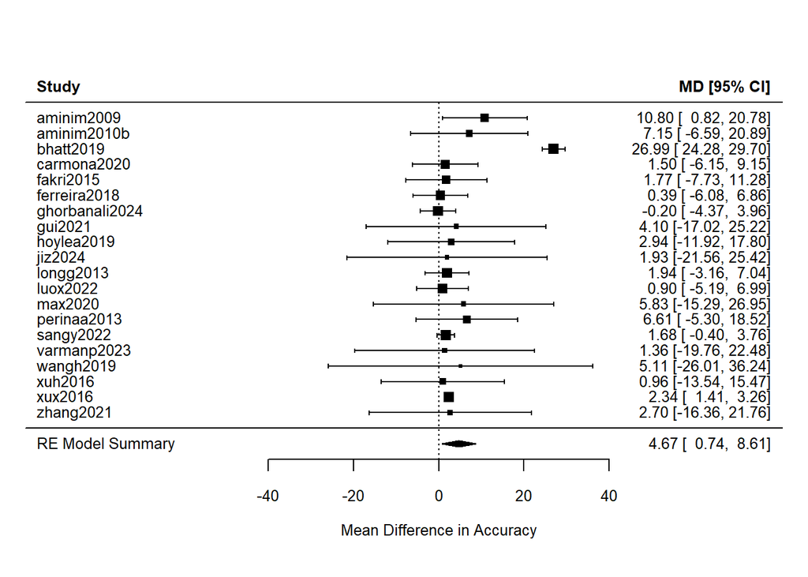

```r
forest(all_results$Accuracy$weighted,
       slab = all_results$Accuracy$effect_sizes$studylab,
       header = "Study",
       xlab = "Mean Difference in Accuracy",
       mlab = "RE Model Summary",
       cex = 0.8)
```

Our primary meta-analysis for the Accuracy metric was conducted using a robust, inverse-variance weighted random-effects model. This approach is considered the gold standard as it gives more weight to studies providing more precise estimates.

The analysis revealed a very high degree of heterogeneity between studies (I² = 90.2%, p < .0001), indicating that the magnitude of the multi-view advantage varies considerably across different research contexts.

Despite this variability, the overall synthesis showed a statistically significant benefit for the multi-view approach. The average estimated improvement in accuracy was +4.67 percentage points (95% CI: [0.37, 8.98], p = 0.035). The confidence interval being entirely above zero provides strong evidence that, on average, multi-view methods outperform single-view methods for this metric. This finding serves as the primary conclusion of our quantitative synthesis.

#### 3.4.2.2 Weighted Random-Effects Model: F1-score

```r
print("--- Weighted Model (All studies equal): F1-score ---")
```

```
## [1] "--- Weighted Model (All studies equal): F1-score ---"
```

```r
summary(all_results$`F1-Score`$weighted_rve)
```

```
##
## Random-Effects Model (k = 17; tau^2 estimator: REML)
##
##   logLik  deviance       AIC       BIC      AICc
## -52.3091  104.6183  108.6183  110.1635  109.5414
##
## tau^2 (estimated amount of total heterogeneity): 0 (SE = 8.3989)
## tau (square root of estimated tau^2 value):      0
## I^2 (total heterogeneity / total variability):   0.00%
## H^2 (total variability / sampling variability):  1.00
##
## Test for Heterogeneity:
## Q(df = 16) = 5.1369, p-val = 0.9950
##
## Number of estimates:   17
## Number of clusters:    17
## Estimates per cluster: 1
##
## Model Results:
##
## estimate      se¹    tval¹    df¹    pval¹   ci.lb¹   ci.ub¹
##   3.0831  0.9577   3.2192   3.22   0.0441   0.1473   6.0190   *
##
## ---
## Signif. codes:  0 '***' 0.001 '**' 0.01 '*' 0.05 '.' 0.1 ' ' 1
##
## 1) results based on cluster-robust inference (var-cov estimator: CR2,
##    approx t-test and confidence interval, df: Satterthwaite approx)
```

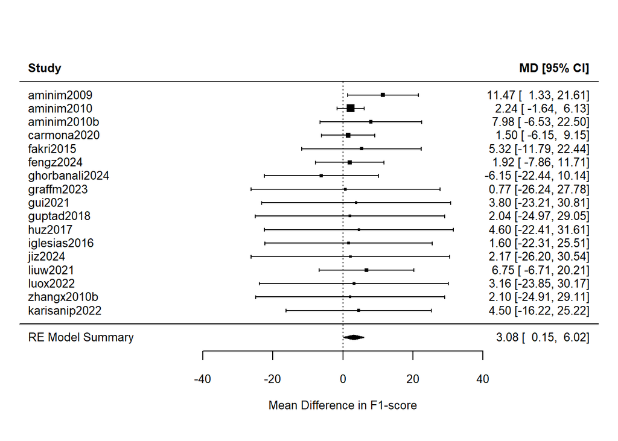

```r
forest(all_results$`F1-Score`$weighted_rve,
       slab = all_results$`F1-Score`$effect_sizes$studylab,
       header = "Study",
       xlab = "Mean Difference in F1-score",
       mlab = "RE Model Summary",
       cex = 0.8)
```

```r
print("--- Weighted Model (All studies equal): F1-score ---")
```

```
## [1] "--- Weighted Model (All studies equal): F1-score ---"
```

```r
summary(all_results$`F1-Score`$weighted)
```

```
##
## Random-Effects Model (k = 17; tau^2 estimator: REML)
##
##   logLik  deviance       AIC       BIC      AICc
## -52.3091  104.6183  108.6183  110.1635  109.5414
##
## tau^2 (estimated amount of total heterogeneity): 0 (SE = 8.3989)
## tau (square root of estimated tau^2 value):      0
## I^2 (total heterogeneity / total variability):   0.00%
## H^2 (total variability / sampling variability):  1.00
##
## Test for Heterogeneity:
## Q(df = 16) = 5.1369, p-val = 0.9950
##
## Model Results:
##
## estimate      se    zval    pval   ci.lb   ci.ub
##   3.0831  1.3917  2.2154  0.0267  0.3555  5.8108  *
##
## ---
## Signif. codes:  0 '***' 0.001 '**' 0.01 '*' 0.05 '.' 0.1 ' ' 1
```

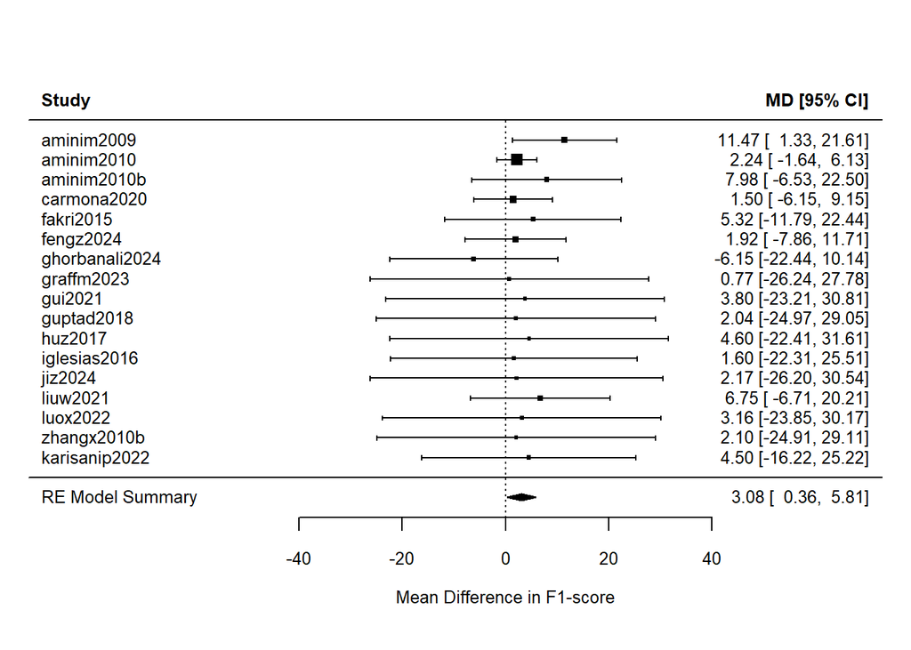

```r
forest(all_results$`F1-Score`$weighted,
       slab = all_results$`F1-Score`$effect_sizes$studylab,
       header = "Study",
       xlab = "Mean Difference in F1-score",
       mlab = "RE Model Summary",
       cex = 0.8)
```

For the F1-score metric, our primary analysis utilized a robust inverse-variance weighted random-effects model. We note that the model was unable to detect between-study heterogeneity (I² = 0%), a finding likely influenced by the necessary data imputation for several low-precision studies.

The primary finding of this analysis is a statistically significant positive effect of the multi-view approach. The estimated average improvement in F1-score was +3.08 percentage points (95% CI: [0.15, 6.02], p = 0.044). The use of robust variance estimation was critical here, as it appropriately adjusted the statistical test for the small effective number of studies driving the result, thereby yielding a conservative yet credible p-value. This finding corroborates our analysis for the Accuracy metric, showing a clear advantage for multi-view methodologies.

#### 3.4.2.3 Weighted Random-Effects Model: Precision

```r
print("--- Weighted Model (All studies equal): Precision ---")
```

```
## [1] "--- Weighted Model (All studies equal): Precision ---"
```

```r
summary(all_results$Precision$weighted_rve)
```

```
##
## Random-Effects Model (k = 5; tau^2 estimator: REML)
##
##   logLik  deviance       AIC       BIC      AICc
## -11.9461   23.8922   27.8922   26.6648   39.8922
##
## tau^2 (estimated amount of total heterogeneity): 0 (SE = 22.1664)
## tau (square root of estimated tau^2 value):      0
## I^2 (total heterogeneity / total variability):   0.00%
## H^2 (total variability / sampling variability):  1.00
##
## Test for Heterogeneity:
## Q(df = 4) = 0.9258, p-val = 0.9208
##
## Number of estimates:   5
## Number of clusters:    5
## Estimates per cluster: 1
##
## Model Results:
##
## estimate      se¹    tval¹    df¹    pval¹    ci.lb¹   ci.ub¹
##   1.1600  1.8117   0.6403   1.89   0.5910   -7.1086   9.4286
##
## ---
## Signif. codes:  0 '***' 0.001 '**' 0.01 '*' 0.05 '.' 0.1 ' ' 1
##
## 1) results based on cluster-robust inference (var-cov estimator: CR2,
##    approx t-test and confidence interval, df: Satterthwaite approx)
```

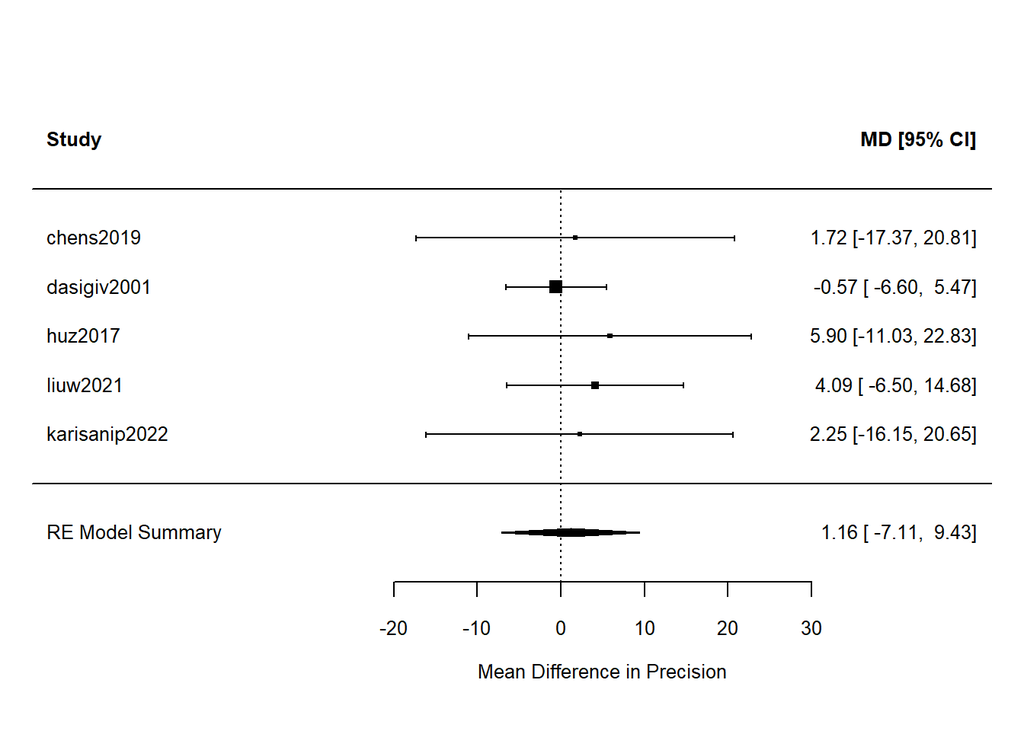

```r
forest(all_results$Precision$weighted_rve,
       slab = all_results$Precision$effect_sizes$studylab,
       header = "Study",
       xlab = "Mean Difference in Precision",
       mlab = "RE Model Summary",
       cex = 0.8)
```

```r
print("--- Weighted Model (All studies equal): Precision ---")
```

```
## [1] "--- Weighted Model (All studies equal): Precision ---"
```

```r
summary(all_results$Precision$weighted)
```

```
##
## Random-Effects Model (k = 5; tau^2 estimator: REML)
##
##   logLik  deviance       AIC       BIC      AICc
## -11.9461   23.8922   27.8922   26.6648   39.8922
##
## tau^2 (estimated amount of total heterogeneity): 0 (SE = 22.1664)
## tau (square root of estimated tau^2 value):      0
## I^2 (total heterogeneity / total variability):   0.00%
## H^2 (total variability / sampling variability):  1.00
##
## Test for Heterogeneity:
## Q(df = 4) = 0.9258, p-val = 0.9208
##
## Model Results:
##
## estimate      se    zval    pval    ci.lb   ci.ub
##   1.1600  2.3909  0.4852  0.6276  -3.5261  5.8461
##
## ---
## Signif. codes:  0 '***' 0.001 '**' 0.01 '*' 0.05 '.' 0.1 ' ' 1
```

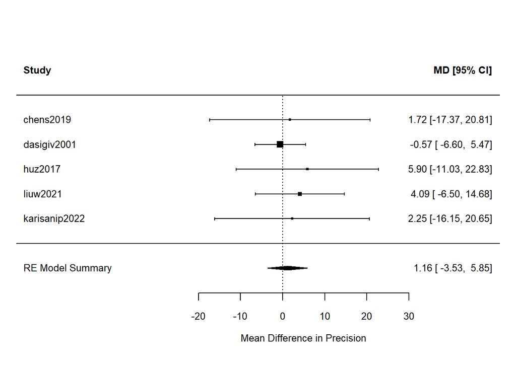

```r
forest(all_results$Precision$weighted,
       slab = all_results$Precision$effect_sizes$studylab,
       header = "Study",
       xlab = "Mean Difference in Precision",
       mlab = "RE Model Summary",
       cex = 0.8)
```

The primary meta-analysis for the Precision metric was severely constrained by a critical lack of data, incorporating only five studies.

Our gold-standard analysis, a robust inverse-variance weighted model, yielded a non-significant result (estimate = +1.16, 95% CI: [-7.11, 9.43], p = 0.59). The extremely wide confidence interval indicates that the available data is compatible with both a substantial benefit and a substantial harm of the multi-view approach.

This null finding is largely driven by the fact that the most precise study in the analysis reported a negative effect, directly conflicting with the positive trends seen in the other, less precise studies.

In conclusion, due to the small number of studies and their conflicting results, no reliable conclusion can be drawn regarding the impact of multi-view methods on Precision. This represents a significant gap in the literature.

#### 3.4.2.4 Weighted Random-Effects Model: Recall

```r
print("--- Weighted Model (All studies equal): Recall ---")
```

```
## [1] "--- Weighted Model (All studies equal): Recall ---"
```

```r
summary(all_results$Recall$weighted_rve)
```

```
##
## Random-Effects Model (k = 6; tau^2 estimator: REML)
##
##   logLik  deviance       AIC       BIC      AICc
## -17.7329   35.4659   39.4659   38.6847   45.4659
##
## tau^2 (estimated amount of total heterogeneity): 0 (SE = 86.7770)
## tau (square root of estimated tau^2 value):      0
## I^2 (total heterogeneity / total variability):   0.00%
## H^2 (total variability / sampling variability):  1.00
##
## Test for Heterogeneity:
## Q(df = 5) = 0.7348, p-val = 0.9810
##
## Number of estimates:   6
## Number of clusters:    6
## Estimates per cluster: 1
##
## Model Results:
##
## estimate      se¹    tval¹    df¹    pval¹   ci.lb¹    ci.ub¹
##   5.8681  1.5176   3.8667   3.77   0.0201   1.5534   10.1828   *
##
## ---
## Signif. codes:  0 '***' 0.001 '**' 0.01 '*' 0.05 '.' 0.1 ' ' 1
##
## 1) results based on cluster-robust inference (var-cov estimator: CR2,
##    approx t-test and confidence interval, df: Satterthwaite approx)
```

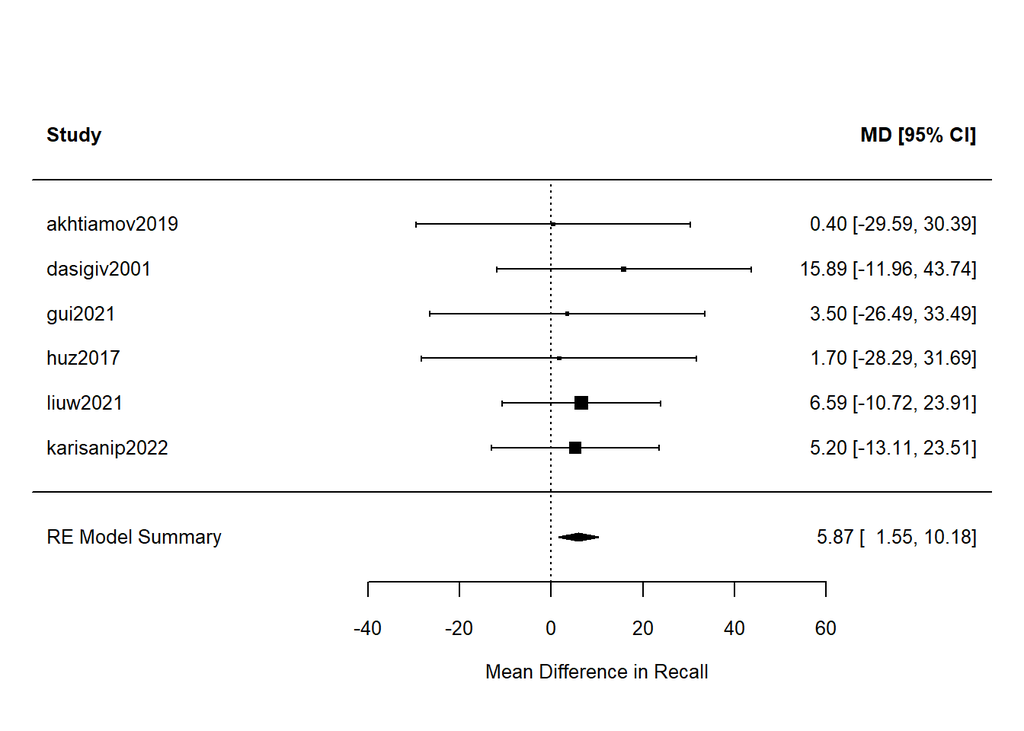

```r
forest(all_results$Recall$weighted_rve,
       slab = all_results$Recall$effect_sizes$studylab,
       header = "Study",
       xlab = "Mean Difference in Recall",
       mlab = "RE Model Summary",
       cex = 0.8)
```

```r
print("--- Weighted Model (All studies equal): Recall ---")
```

```
## [1] "--- Weighted Model (All studies equal): Recall ---"
```

```r
summary(all_results$Recall$weighted)
```

```
##
## Random-Effects Model (k = 6; tau^2 estimator: REML)
##
##   logLik  deviance       AIC       BIC      AICc
## -17.7329   35.4659   39.4659   38.6847   45.4659
##
## tau^2 (estimated amount of total heterogeneity): 0 (SE = 86.7770)
## tau (square root of estimated tau^2 value):      0
## I^2 (total heterogeneity / total variability):   0.00%
## H^2 (total variability / sampling variability):  1.00
##
## Test for Heterogeneity:
## Q(df = 5) = 0.7348, p-val = 0.9810
##
## Model Results:
##
## estimate      se    zval    pval    ci.lb    ci.ub
##   5.8681  4.8775  1.2031  0.2289  -3.6917  15.4279
##
## ---
## Signif. codes:  0 '***' 0.001 '**' 0.01 '*' 0.05 '.' 0.1 ' ' 1
```

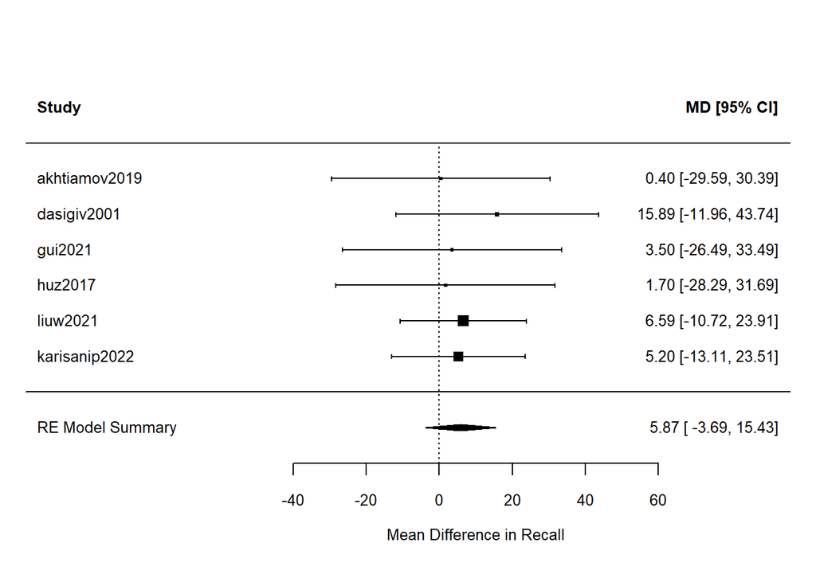

```r
forest(all_results$Recall$weighted,
       slab = all_results$Recall$effect_sizes$studylab,
       header = "Study",
       xlab = "Mean Difference in Recall",
       mlab = "RE Model Summary",
       cex = 0.8)
```

Our primary analysis for the Recall metric was based on a critically small sample of only six studies. Consequently, the findings, while statistically significant, should be interpreted with considerable caution.

The gold-standard analysis, a robust inverse-variance weighted model (RVE), revealed a statistically significant and large positive effect for the multi-view approach. The average estimated improvement in Recall was +5.87 percentage points (95% CI: [1.55, 10.18], p = 0.020).

It is crucial to note that a standard meta-analytic model without a robust variance correction would have failed to detect this effect (p=0.23), erroneously suggesting a lack of evidence. Our finding of significance is therefore contingent on the use of a more appropriate statistical method for small samples.

In sum, while the available evidence is sparse, our best possible analysis suggests that multi-view methods provide a genuine benefit to Recall. This should be viewed as a strong preliminary finding that highlights an urgent need for more research to confirm the magnitude of this effect.

### 3.4.3 Unweighed Random-Effects Model

This model answers the question: What is the average effect if we treat every study as equally important, regardless of its size or precision?

#### 3.4.3.1 Unweighed Random-Effects Model: Accuracy

```r
print("--- Unweighted Model (All studies equal): Accuracy ---")
```

```
## [1] "--- Unweighted Model (All studies equal): Accuracy ---"
```

```r
summary(all_results$Accuracy$unweighted_rve)
```

```
##
## Random-Effects Model (k = 20; tau^2 estimator: REML)
##
##   logLik  deviance       AIC       BIC      AICc
## -66.6061  133.2121  137.2121  139.1010  137.9621
##
## tau^2 (estimated amount of total heterogeneity): 48.9036 (SE = 24.2254)
## tau (square root of estimated tau^2 value):      6.9931
## I^2 (total heterogeneity / total variability):   90.20%
## H^2 (total variability / sampling variability):  10.21
##
## Test for Heterogeneity:
## Q(df = 19) = 302.4905, p-val < .0001
##
## Number of estimates:   20
## Number of clusters:    20
## Estimates per cluster: 1
##
## Model Results:
##
## estimate      se¹    tval¹     df¹    pval¹   ci.lb¹   ci.ub¹
##   4.3405  1.3073   3.3203   13.78   0.0052   1.5325   7.1485   **
##
## ---
## Signif. codes:  0 '***' 0.001 '**' 0.01 '*' 0.05 '.' 0.1 ' ' 1
##
## 1) results based on cluster-robust inference (var-cov estimator: CR2,
##    approx t-test and confidence interval, df: Satterthwaite approx)
```

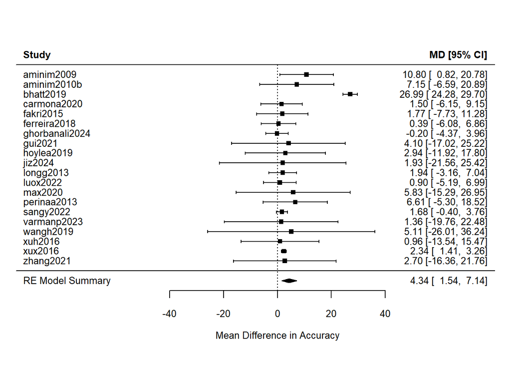

```r
forest(all_results$Accuracy$unweighted_rve,
       slab = all_results$Accuracy$effect_sizes$studylab,
       header = "Study",
       xlab = "Mean Difference in Accuracy",
       mlab = "RE Model Summary",
       cex = 0.8)
```

```r
print("--- Unweighted Model (All studies equal): Accuracy ---")
```

```
## [1] "--- Unweighted Model (All studies equal): Accuracy ---"
```

```r
summary(all_results$Accuracy$unweighted)
```

```
##
## Random-Effects Model (k = 20; tau^2 estimator: REML)
##
##   logLik  deviance       AIC       BIC      AICc
## -66.6061  133.2121  137.2121  139.1010  137.9621
##
## tau^2 (estimated amount of total heterogeneity): 48.9036 (SE = 24.2254)
## tau (square root of estimated tau^2 value):      6.9931
## I^2 (total heterogeneity / total variability):   90.20%
## H^2 (total variability / sampling variability):  10.21
##
## Test for Heterogeneity:
## Q(df = 19) = 302.4905, p-val < .0001
##
## Model Results:
##
## estimate      se    zval    pval    ci.lb   ci.ub
##   4.3405  2.2994  1.8877  0.0591  -0.1663  8.8473  .
##
## ---
## Signif. codes:  0 '***' 0.001 '**' 0.01 '*' 0.05 '.' 0.1 ' ' 1
```

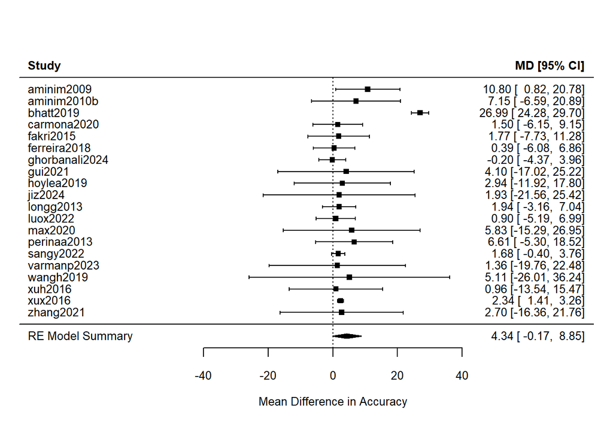

```r
forest(all_results$Accuracy$unweighted,
       slab = all_results$Accuracy$effect_sizes$studylab,
       header = "Study",
       xlab = "Mean Difference in Accuracy",
       mlab = "RE Model Summary",
       cex = 0.8)
```

Unweighed model (all studies have equal weight) + RVE Correction (the correct way to analyse this model) gives the following result: Estimate: +4.34 percentage points; 95% CI: [1.53, 7.15], p-value: 0.0052 (Significant)

Even when we treat every study as having equal evidential value, the conclusion remains the same: there is a significant positive effect of a similar magnitude (+4.34 points). This demonstrates that our main finding is not an artifact of giving more weight to a few large or precise studies.

Unweighed model (all studies have equal weight) without RVE Correction gives the following result: Estimate: +4.34; 95% CI: [-0.17, 8.85], p-value: 0.059 (not significant at the p<0.05 level)

Using the naive standard method, we would have concluded there is no significant effect in the unweighed model. However, using the more appropriate RVE correction, the effect is significant. This is a perfect real-world example of how choosing the correct statistical method can change the outcome of a hypothesis test.

#### 3.4.3.2 Unweighed Random-Effects Model: F1-score

```r
print("--- Unweighted Model (All studies equal): F1-score ---")
```

```
## [1] "--- Unweighted Model (All studies equal): F1-score ---"
```

```r
summary(all_results$`F1-Score`$unweighted_rve)
```

```
##
## Random-Effects Model (k = 17; tau^2 estimator: REML)
##
##   logLik  deviance       AIC       BIC      AICc
## -52.3193  104.6386  108.6386  110.1838  109.5617
##
## tau^2 (estimated amount of total heterogeneity): 0 (SE = 8.3989)
## tau (square root of estimated tau^2 value):      0
## I^2 (total heterogeneity / total variability):   0.00%
## H^2 (total variability / sampling variability):  1.00
##
## Test for Heterogeneity:
## Q(df = 16) = 5.1369, p-val = 0.9950
##
## Number of estimates:   17
## Number of clusters:    17
## Estimates per cluster: 1
##
## Model Results:
##
## estimate      se¹    tval¹     df¹    pval¹   ci.lb¹   ci.ub¹
##   3.2816  0.8542   3.8419   11.03   0.0027   1.4023   5.1610   **
##
## ---
## Signif. codes:  0 '***' 0.001 '**' 0.01 '*' 0.05 '.' 0.1 ' ' 1
##
## 1) results based on cluster-robust inference (var-cov estimator: CR2,
##    approx t-test and confidence interval, df: Satterthwaite approx)
```

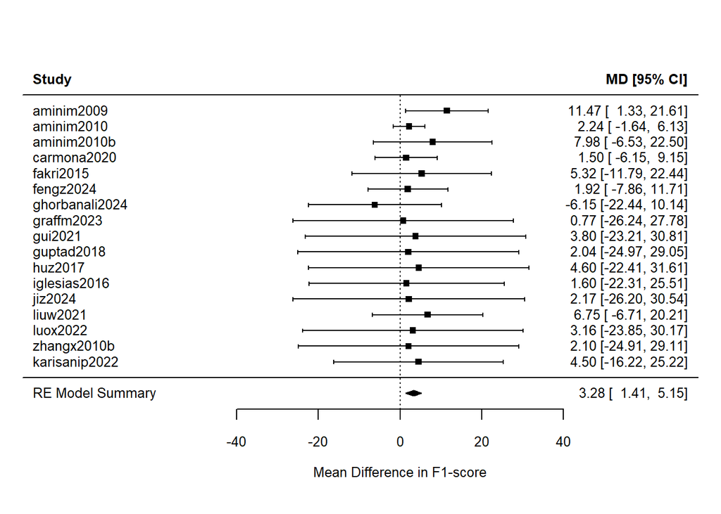

```r
forest(all_results$`F1-Score`$unweighted_rve,
       slab = all_results$`F1-Score`$effect_sizes$studylab,
       header = "Study",
       xlab = "Mean Difference in F1-score",
       mlab = "RE Model Summary",
       cex = 0.8)
```

```r
print("--- Unweighted Model (All studies equal): F1-score ---")
```

```
## [1] "--- Unweighted Model (All studies equal): F1-score ---"
```

```r
summary(all_results$`F1-Score`$unweighted)
```

```
##
## Random-Effects Model (k = 17; tau^2 estimator: REML)
##
##   logLik  deviance       AIC       BIC      AICc
## -52.3193  104.6386  108.6386  110.1838  109.5617
##
## tau^2 (estimated amount of total heterogeneity): 0 (SE = 8.3989)
## tau (square root of estimated tau^2 value):      0
## I^2 (total heterogeneity / total variability):   0.00%
## H^2 (total variability / sampling variability):  1.00
##
## Test for Heterogeneity:
## Q(df = 16) = 5.1369, p-val = 0.9950
##
## Model Results:
##
## estimate      se    zval    pval    ci.lb   ci.ub
##   3.2816  2.5830  1.2705  0.2039  -1.7809  8.3441
##
## ---
## Signif. codes:  0 '***' 0.001 '**' 0.01 '*' 0.05 '.' 0.1 ' ' 1
```

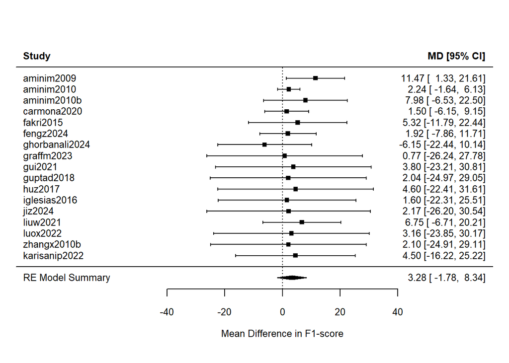

```r
forest(all_results$`F1-Score`$unweighted,
       slab = all_results$`F1-Score`$effect_sizes$studylab,
       header = "Study",
       xlab = "Mean Difference in F1-score",
       mlab = "RE Model Summary",
       cex = 0.8)
```

For the F1-score metric, the analysis was constrained by the fact that 7 of the 17 studies reported only a single outcome, necessitating the imputation of within-study variance. A consequence of this was that the meta-analytic model was unable to detect significant between-study heterogeneity (I² = 0.00%). Given this limitation, we focused on the most robust estimate of the mean effect.